# PS5_EuiYulSong

## 1 Active data exploration

```python
# Let's import the important packages.  Depending on how do your
# exactly proceed, you may need more.

# Numpy is a library for working with Arrays
import numpy as np
print("Numpy version:        %6.6s" % np.__version__)

# SciPy implements many different numerical algorithms
import scipy as sp
print("SciPy version:        %6.6s" % sp.__version__)

# Pandas makes working with data tables easier
import pandas as pd
print("Pandas version:       %6.6s" % pd.__version__)

# Module for plotting
import matplotlib
print("Maplotlib version:    %6.6s" % matplotlib.__version__)
%matplotlib inline
# needed for inline plots in notebooks
import matplotlib.pyplot as plt

# SciKit Learn implements several Machine Learning algorithms
import sklearn
print("Scikit-Learn version: %6.6s" % sklearn.__version__)
```

```
Numpy version:        1.13.3
SciPy version:        0.19.1
Pandas version:       0.20.3
Maplotlib version:     2.1.0
Scikit-Learn version: 0.19.1
```

## 1. Load the data

```python
from sklearn.datasets import load_boston
bdata = load_boston()
```

```python
print(bdata.keys())
print(bdata.feature_names)
print(bdata.data.shape)
print(bdata.target.shape)
# uncomment the following if you want to see a lengthy description of the dataset
print(bdata.DESCR)
```

```
dict_keys(['data', 'target', 'feature_names', 'DESCR'])
['CRIM' 'ZN' 'INDUS' 'CHAS' 'NOX' 'RM' 'AGE' 'DIS' 'RAD' 'TAX' 'PTRATIO'
 'B' 'LSTAT']
(506, 13)
(506,)
Boston House Prices dataset
===========================

Notes
------
Data Set Characteristics:

    :Number of Instances: 506

    :Number of Attributes: 13 numeric/categorical predictive

    :Median Value (attribute 14) is usually the target

    :Attribute Information (in order):
        - CRIM     per capita crime rate by town
        - ZN       proportion of residential land zoned for lots over 25,000 sq.ft.
        - INDUS    proportion of non-retail business acres per town
        - CHAS     Charles River dummy variable (= 1 if tract bounds river; 0 otherwise)
        - NOX      nitric oxides concentration (parts per 10 million)
        - RM       average number of rooms per dwelling
        - AGE      proportion of owner-occupied units built prior to 1940
        - DIS      weighted distances to five Boston employment centres
        - RAD      index of accessibility to radial highways
        - TAX      full-value property-tax rate per $10,000
        - PTRATIO  pupil-teacher ratio by town
        - B        1000(Bk - 0.63)^2 where Bk is the proportion of blacks by town
        - LSTAT    % lower status of the population
        - MEDV     Median value of owner-occupied homes in $1000's

    :Missing Attribute Values: None

    :Creator: Harrison, D. and Rubinfeld, D.L.

This is a copy of UCI ML housing dataset.
http://archive.ics.uci.edu/ml/datasets/Housing


This dataset was taken from the StatLib library which is maintained at Carnegie Mellon University.

The Boston house-price data of Harrison, D. and Rubinfeld, D.L. 'Hedonic
prices and the demand for clean air', J. Environ. Economics & Management,
vol.5, 81-102, 1978.   Used in Belsley, Kuh & Welsch, 'Regression diagnostics
...', Wiley, 1980.   N.B. Various transformations are used in the table on
pages 244-261 of the latter.

The Boston house-price data has been used in many machine learning papers that address regression
problems.

**References**

   - Belsley, Kuh & Welsch, 'Regression diagnostics: Identifying Influential Data and Sources of Collinearity', Wiley, 1980. 244-261.
   - Quinlan,R. (1993). Combining Instance-Based and Model-Based Learning. In Proceedings on the Tenth International Conference of Machine Learning, 236-243, University of Massachusetts, Amherst. Morgan Kaufmann.
   - many more! (see http://archive.ics.uci.edu/ml/datasets/Housing)
```

```python
boston = pd.DataFrame(bdata.data, columns = bdata.feature_names)
boston
```

|  | CRIM | ZN | INDUS | CHAS | NOX | RM | AGE | DIS | RAD | TAX | PTRATIO | B | LSTAT |
| --- | --- | --- | --- | --- | --- | --- | --- | --- | --- | --- | --- | --- | --- |
| 0 | 0.00632 | 18.0 | 2.31 | 0.0 | 0.538 | 6.575 | 65.2 | 4.0900 | 1.0 | 296.0 | 15.3 | 396.90 | 4.98 |
| 1 | 0.02731 | 0.0 | 7.07 | 0.0 | 0.469 | 6.421 | 78.9 | 4.9671 | 2.0 | 242.0 | 17.8 | 396.90 | 9.14 |
| 2 | 0.02729 | 0.0 | 7.07 | 0.0 | 0.469 | 7.185 | 61.1 | 4.9671 | 2.0 | 242.0 | 17.8 | 392.83 | 4.03 |
| 3 | 0.03237 | 0.0 | 2.18 | 0.0 | 0.458 | 6.998 | 45.8 | 6.0622 | 3.0 | 222.0 | 18.7 | 394.63 | 2.94 |
| 4 | 0.06905 | 0.0 | 2.18 | 0.0 | 0.458 | 7.147 | 54.2 | 6.0622 | 3.0 | 222.0 | 18.7 | 396.90 | 5.33 |
| 5 | 0.02985 | 0.0 | 2.18 | 0.0 | 0.458 | 6.430 | 58.7 | 6.0622 | 3.0 | 222.0 | 18.7 | 394.12 | 5.21 |
| 6 | 0.08829 | 12.5 | 7.87 | 0.0 | 0.524 | 6.012 | 66.6 | 5.5605 | 5.0 | 311.0 | 15.2 | 395.60 | 12.43 |
| 7 | 0.14455 | 12.5 | 7.87 | 0.0 | 0.524 | 6.172 | 96.1 | 5.9505 | 5.0 | 311.0 | 15.2 | 396.90 | 19.15 |
| 8 | 0.21124 | 12.5 | 7.87 | 0.0 | 0.524 | 5.631 | 100.0 | 6.0821 | 5.0 | 311.0 | 15.2 | 386.63 | 29.93 |
| 9 | 0.17004 | 12.5 | 7.87 | 0.0 | 0.524 | 6.004 | 85.9 | 6.5921 | 5.0 | 311.0 | 15.2 | 386.71 | 17.10 |
| 10 | 0.22489 | 12.5 | 7.87 | 0.0 | 0.524 | 6.377 | 94.3 | 6.3467 | 5.0 | 311.0 | 15.2 | 392.52 | 20.45 |
| 11 | 0.11747 | 12.5 | 7.87 | 0.0 | 0.524 | 6.009 | 82.9 | 6.2267 | 5.0 | 311.0 | 15.2 | 396.90 | 13.27 |
| 12 | 0.09378 | 12.5 | 7.87 | 0.0 | 0.524 | 5.889 | 39.0 | 5.4509 | 5.0 | 311.0 | 15.2 | 390.50 | 15.71 |
| 13 | 0.62976 | 0.0 | 8.14 | 0.0 | 0.538 | 5.949 | 61.8 | 4.7075 | 4.0 | 307.0 | 21.0 | 396.90 | 8.26 |
| 14 | 0.63796 | 0.0 | 8.14 | 0.0 | 0.538 | 6.096 | 84.5 | 4.4619 | 4.0 | 307.0 | 21.0 | 380.02 | 10.26 |
| 15 | 0.62739 | 0.0 | 8.14 | 0.0 | 0.538 | 5.834 | 56.5 | 4.4986 | 4.0 | 307.0 | 21.0 | 395.62 | 8.47 |
| 16 | 1.05393 | 0.0 | 8.14 | 0.0 | 0.538 | 5.935 | 29.3 | 4.4986 | 4.0 | 307.0 | 21.0 | 386.85 | 6.58 |
| 17 | 0.78420 | 0.0 | 8.14 | 0.0 | 0.538 | 5.990 | 81.7 | 4.2579 | 4.0 | 307.0 | 21.0 | 386.75 | 14.67 |
| 18 | 0.80271 | 0.0 | 8.14 | 0.0 | 0.538 | 5.456 | 36.6 | 3.7965 | 4.0 | 307.0 | 21.0 | 288.99 | 11.69 |
| 19 | 0.72580 | 0.0 | 8.14 | 0.0 | 0.538 | 5.727 | 69.5 | 3.7965 | 4.0 | 307.0 | 21.0 | 390.95 | 11.28 |
| 20 | 1.25179 | 0.0 | 8.14 | 0.0 | 0.538 | 5.570 | 98.1 | 3.7979 | 4.0 | 307.0 | 21.0 | 376.57 | 21.02 |
| 21 | 0.85204 | 0.0 | 8.14 | 0.0 | 0.538 | 5.965 | 89.2 | 4.0123 | 4.0 | 307.0 | 21.0 | 392.53 | 13.83 |
| 22 | 1.23247 | 0.0 | 8.14 | 0.0 | 0.538 | 6.142 | 91.7 | 3.9769 | 4.0 | 307.0 | 21.0 | 396.90 | 18.72 |
| 23 | 0.98843 | 0.0 | 8.14 | 0.0 | 0.538 | 5.813 | 100.0 | 4.0952 | 4.0 | 307.0 | 21.0 | 394.54 | 19.88 |
| 24 | 0.75026 | 0.0 | 8.14 | 0.0 | 0.538 | 5.924 | 94.1 | 4.3996 | 4.0 | 307.0 | 21.0 | 394.33 | 16.30 |
| 25 | 0.84054 | 0.0 | 8.14 | 0.0 | 0.538 | 5.599 | 85.7 | 4.4546 | 4.0 | 307.0 | 21.0 | 303.42 | 16.51 |
| 26 | 0.67191 | 0.0 | 8.14 | 0.0 | 0.538 | 5.813 | 90.3 | 4.6820 | 4.0 | 307.0 | 21.0 | 376.88 | 14.81 |
| 27 | 0.95577 | 0.0 | 8.14 | 0.0 | 0.538 | 6.047 | 88.8 | 4.4534 | 4.0 | 307.0 | 21.0 | 306.38 | 17.28 |
| 28 | 0.77299 | 0.0 | 8.14 | 0.0 | 0.538 | 6.495 | 94.4 | 4.4547 | 4.0 | 307.0 | 21.0 | 387.94 | 12.80 |
| 29 | 1.00245 | 0.0 | 8.14 | 0.0 | 0.538 | 6.674 | 87.3 | 4.2390 | 4.0 | 307.0 | 21.0 | 380.23 | 11.98 |
| ... | ... | ... | ... | ... | ... | ... | ... | ... | ... | ... | ... | ... | ... |
| 476 | 4.87141 | 0.0 | 18.10 | 0.0 | 0.614 | 6.484 | 93.6 | 2.3053 | 24.0 | 666.0 | 20.2 | 396.21 | 18.68 |
| 477 | 15.02340 | 0.0 | 18.10 | 0.0 | 0.614 | 5.304 | 97.3 | 2.1007 | 24.0 | 666.0 | 20.2 | 349.48 | 24.91 |
| 478 | 10.23300 | 0.0 | 18.10 | 0.0 | 0.614 | 6.185 | 96.7 | 2.1705 | 24.0 | 666.0 | 20.2 | 379.70 | 18.03 |
| 479 | 14.33370 | 0.0 | 18.10 | 0.0 | 0.614 | 6.229 | 88.0 | 1.9512 | 24.0 | 666.0 | 20.2 | 383.32 | 13.11 |
| 480 | 5.82401 | 0.0 | 18.10 | 0.0 | 0.532 | 6.242 | 64.7 | 3.4242 | 24.0 | 666.0 | 20.2 | 396.90 | 10.74 |
| 481 | 5.70818 | 0.0 | 18.10 | 0.0 | 0.532 | 6.750 | 74.9 | 3.3317 | 24.0 | 666.0 | 20.2 | 393.07 | 7.74 |
| 482 | 5.73116 | 0.0 | 18.10 | 0.0 | 0.532 | 7.061 | 77.0 | 3.4106 | 24.0 | 666.0 | 20.2 | 395.28 | 7.01 |
| 483 | 2.81838 | 0.0 | 18.10 | 0.0 | 0.532 | 5.762 | 40.3 | 4.0983 | 24.0 | 666.0 | 20.2 | 392.92 | 10.42 |
| 484 | 2.37857 | 0.0 | 18.10 | 0.0 | 0.583 | 5.871 | 41.9 | 3.7240 | 24.0 | 666.0 | 20.2 | 370.73 | 13.34 |
| 485 | 3.67367 | 0.0 | 18.10 | 0.0 | 0.583 | 6.312 | 51.9 | 3.9917 | 24.0 | 666.0 | 20.2 | 388.62 | 10.58 |
| 486 | 5.69175 | 0.0 | 18.10 | 0.0 | 0.583 | 6.114 | 79.8 | 3.5459 | 24.0 | 666.0 | 20.2 | 392.68 | 14.98 |
| 487 | 4.83567 | 0.0 | 18.10 | 0.0 | 0.583 | 5.905 | 53.2 | 3.1523 | 24.0 | 666.0 | 20.2 | 388.22 | 11.45 |
| 488 | 0.15086 | 0.0 | 27.74 | 0.0 | 0.609 | 5.454 | 92.7 | 1.8209 | 4.0 | 711.0 | 20.1 | 395.09 | 18.06 |
| 489 | 0.18337 | 0.0 | 27.74 | 0.0 | 0.609 | 5.414 | 98.3 | 1.7554 | 4.0 | 711.0 | 20.1 | 344.05 | 23.97 |
| 490 | 0.20746 | 0.0 | 27.74 | 0.0 | 0.609 | 5.093 | 98.0 | 1.8226 | 4.0 | 711.0 | 20.1 | 318.43 | 29.68 |
| 491 | 0.10574 | 0.0 | 27.74 | 0.0 | 0.609 | 5.983 | 98.8 | 1.8681 | 4.0 | 711.0 | 20.1 | 390.11 | 18.07 |
| 492 | 0.11132 | 0.0 | 27.74 | 0.0 | 0.609 | 5.983 | 83.5 | 2.1099 | 4.0 | 711.0 | 20.1 | 396.90 | 13.35 |
| 493 | 0.17331 | 0.0 | 9.69 | 0.0 | 0.585 | 5.707 | 54.0 | 2.3817 | 6.0 | 391.0 | 19.2 | 396.90 | 12.01 |
| 494 | 0.27957 | 0.0 | 9.69 | 0.0 | 0.585 | 5.926 | 42.6 | 2.3817 | 6.0 | 391.0 | 19.2 | 396.90 | 13.59 |
| 495 | 0.17899 | 0.0 | 9.69 | 0.0 | 0.585 | 5.670 | 28.8 | 2.7986 | 6.0 | 391.0 | 19.2 | 393.29 | 17.60 |
| 496 | 0.28960 | 0.0 | 9.69 | 0.0 | 0.585 | 5.390 | 72.9 | 2.7986 | 6.0 | 391.0 | 19.2 | 396.90 | 21.14 |
| 497 | 0.26838 | 0.0 | 9.69 | 0.0 | 0.585 | 5.794 | 70.6 | 2.8927 | 6.0 | 391.0 | 19.2 | 396.90 | 14.10 |
| 498 | 0.23912 | 0.0 | 9.69 | 0.0 | 0.585 | 6.019 | 65.3 | 2.4091 | 6.0 | 391.0 | 19.2 | 396.90 | 12.92 |
| 499 | 0.17783 | 0.0 | 9.69 | 0.0 | 0.585 | 5.569 | 73.5 | 2.3999 | 6.0 | 391.0 | 19.2 | 395.77 | 15.10 |
| 500 | 0.22438 | 0.0 | 9.69 | 0.0 | 0.585 | 6.027 | 79.7 | 2.4982 | 6.0 | 391.0 | 19.2 | 396.90 | 14.33 |
| 501 | 0.06263 | 0.0 | 11.93 | 0.0 | 0.573 | 6.593 | 69.1 | 2.4786 | 1.0 | 273.0 | 21.0 | 391.99 | 9.67 |
| 502 | 0.04527 | 0.0 | 11.93 | 0.0 | 0.573 | 6.120 | 76.7 | 2.2875 | 1.0 | 273.0 | 21.0 | 396.90 | 9.08 |
| 503 | 0.06076 | 0.0 | 11.93 | 0.0 | 0.573 | 6.976 | 91.0 | 2.1675 | 1.0 | 273.0 | 21.0 | 396.90 | 5.64 |
| 504 | 0.10959 | 0.0 | 11.93 | 0.0 | 0.573 | 6.794 | 89.3 | 2.3889 | 1.0 | 273.0 | 21.0 | 393.45 | 6.48 |
| 505 | 0.04741 | 0.0 | 11.93 | 0.0 | 0.573 | 6.030 | 80.8 | 2.5050 | 1.0 | 273.0 | 21.0 | 396.90 | 7.88 |

506 rows × 13 columns

## 2. Add some (10 or so) engineered features (synthetic features) to the data. As in the previous problem set, you may use various mathematical operations on a single or multiple features to create new ones.

```python
boston['AGE*TAX'] = boston['AGE'] * boston['TAX']
boston['CRIM/AGE'] = boston['CRIM'] / boston['AGE']
boston['CRIM/B'] = boston['CRIM'] / boston['B']
boston['CRIM**2'] = boston['CRIM']**2
boston['NOX**3'] = boston['NOX']**3
boston['RM*DIS'] = boston['RM'] * boston['DIS']
boston['PTRATIO*B'] = boston['PTRATIO'] * boston['B']
boston['INDUS/NOX'] = boston['INDUS'] / boston['NOX']
boston['ZN*INDUS'] = boston['ZN'] * boston['INDUS']
boston['B/RM'] = boston['B'] / boston['RM']
boston
```

|  | CRIM | ZN | INDUS | CHAS | NOX | RM | AGE | DIS | RAD | TAX | ... | AGE*TAX | CRIM/AGE | CRIM/B | CRIM**2 | NOX**3 | RM*DIS | PTRATIO*B | INDUS/NOX | ZN*INDUS | B/RM |
| --- | --- | --- | --- | --- | --- | --- | --- | --- | --- | --- | --- | --- | --- | --- | --- | --- | --- | --- | --- | --- | --- |
| 0 | 0.00632 | 18.0 | 2.31 | 0.0 | 0.538 | 6.575 | 65.2 | 4.0900 | 1.0 | 296.0 | ... | 19299.2 | 0.000097 | 0.000016 | 0.000040 | 0.155721 | 26.891750 | 6072.570 | 4.293680 | 41.580 | 60.365019 |
| 1 | 0.02731 | 0.0 | 7.07 | 0.0 | 0.469 | 6.421 | 78.9 | 4.9671 | 2.0 | 242.0 | ... | 19093.8 | 0.000346 | 0.000069 | 0.000746 | 0.103162 | 31.893749 | 7064.820 | 15.074627 | 0.000 | 61.812802 |
| 2 | 0.02729 | 0.0 | 7.07 | 0.0 | 0.469 | 7.185 | 61.1 | 4.9671 | 2.0 | 242.0 | ... | 14786.2 | 0.000447 | 0.000069 | 0.000745 | 0.103162 | 35.688614 | 6992.374 | 15.074627 | 0.000 | 54.673626 |
| 3 | 0.03237 | 0.0 | 2.18 | 0.0 | 0.458 | 6.998 | 45.8 | 6.0622 | 3.0 | 222.0 | ... | 10167.6 | 0.000707 | 0.000082 | 0.001048 | 0.096072 | 42.423276 | 7379.581 | 4.759825 | 0.000 | 56.391826 |
| 4 | 0.06905 | 0.0 | 2.18 | 0.0 | 0.458 | 7.147 | 54.2 | 6.0622 | 3.0 | 222.0 | ... | 12032.4 | 0.001274 | 0.000174 | 0.004768 | 0.096072 | 43.326543 | 7422.030 | 4.759825 | 0.000 | 55.533790 |
| 5 | 0.02985 | 0.0 | 2.18 | 0.0 | 0.458 | 6.430 | 58.7 | 6.0622 | 3.0 | 222.0 | ... | 13031.4 | 0.000509 | 0.000076 | 0.000891 | 0.096072 | 38.979946 | 7370.044 | 4.759825 | 0.000 | 61.293935 |
| 6 | 0.08829 | 12.5 | 7.87 | 0.0 | 0.524 | 6.012 | 66.6 | 5.5605 | 5.0 | 311.0 | ... | 20712.6 | 0.001326 | 0.000223 | 0.007795 | 0.143878 | 33.429726 | 6013.120 | 15.019084 | 98.375 | 65.801730 |
| 7 | 0.14455 | 12.5 | 7.87 | 0.0 | 0.524 | 6.172 | 96.1 | 5.9505 | 5.0 | 311.0 | ... | 29887.1 | 0.001504 | 0.000364 | 0.020895 | 0.143878 | 36.726486 | 6032.880 | 15.019084 | 98.375 | 64.306546 |
| 8 | 0.21124 | 12.5 | 7.87 | 0.0 | 0.524 | 5.631 | 100.0 | 6.0821 | 5.0 | 311.0 | ... | 31100.0 | 0.002112 | 0.000546 | 0.044622 | 0.143878 | 34.248305 | 5876.776 | 15.019084 | 98.375 | 68.660984 |
| 9 | 0.17004 | 12.5 | 7.87 | 0.0 | 0.524 | 6.004 | 85.9 | 6.5921 | 5.0 | 311.0 | ... | 26714.9 | 0.001980 | 0.000440 | 0.028914 | 0.143878 | 39.578968 | 5877.992 | 15.019084 | 98.375 | 64.408728 |
| 10 | 0.22489 | 12.5 | 7.87 | 0.0 | 0.524 | 6.377 | 94.3 | 6.3467 | 5.0 | 311.0 | ... | 29327.3 | 0.002385 | 0.000573 | 0.050576 | 0.143878 | 40.472906 | 5966.304 | 15.019084 | 98.375 | 61.552454 |
| 11 | 0.11747 | 12.5 | 7.87 | 0.0 | 0.524 | 6.009 | 82.9 | 6.2267 | 5.0 | 311.0 | ... | 25781.9 | 0.001417 | 0.000296 | 0.013799 | 0.143878 | 37.416240 | 6032.880 | 15.019084 | 98.375 | 66.050924 |
| 12 | 0.09378 | 12.5 | 7.87 | 0.0 | 0.524 | 5.889 | 39.0 | 5.4509 | 5.0 | 311.0 | ... | 12129.0 | 0.002405 | 0.000240 | 0.008795 | 0.143878 | 32.100350 | 5935.600 | 15.019084 | 98.375 | 66.310070 |
| 13 | 0.62976 | 0.0 | 8.14 | 0.0 | 0.538 | 5.949 | 61.8 | 4.7075 | 4.0 | 307.0 | ... | 18972.6 | 0.010190 | 0.001587 | 0.396598 | 0.155721 | 28.004917 | 8334.900 | 15.130112 | 0.000 | 66.717095 |
| 14 | 0.63796 | 0.0 | 8.14 | 0.0 | 0.538 | 6.096 | 84.5 | 4.4619 | 4.0 | 307.0 | ... | 25941.5 | 0.007550 | 0.001679 | 0.406993 | 0.155721 | 27.199742 | 7980.420 | 15.130112 | 0.000 | 62.339239 |
| 15 | 0.62739 | 0.0 | 8.14 | 0.0 | 0.538 | 5.834 | 56.5 | 4.4986 | 4.0 | 307.0 | ... | 17345.5 | 0.011104 | 0.001586 | 0.393618 | 0.155721 | 26.244832 | 8308.020 | 15.130112 | 0.000 | 67.812821 |
| 16 | 1.05393 | 0.0 | 8.14 | 0.0 | 0.538 | 5.935 | 29.3 | 4.4986 | 4.0 | 307.0 | ... | 8995.1 | 0.035970 | 0.002724 | 1.110768 | 0.155721 | 26.699191 | 8123.850 | 15.130112 | 0.000 | 65.181129 |
| 17 | 0.78420 | 0.0 | 8.14 | 0.0 | 0.538 | 5.990 | 81.7 | 4.2579 | 4.0 | 307.0 | ... | 25081.9 | 0.009599 | 0.002028 | 0.614970 | 0.155721 | 25.504821 | 8121.750 | 15.130112 | 0.000 | 64.565943 |
| 18 | 0.80271 | 0.0 | 8.14 | 0.0 | 0.538 | 5.456 | 36.6 | 3.7965 | 4.0 | 307.0 | ... | 11236.2 | 0.021932 | 0.002778 | 0.644343 | 0.155721 | 20.713704 | 6068.790 | 15.130112 | 0.000 | 52.967375 |
| 19 | 0.72580 | 0.0 | 8.14 | 0.0 | 0.538 | 5.727 | 69.5 | 3.7965 | 4.0 | 307.0 | ... | 21336.5 | 0.010443 | 0.001857 | 0.526786 | 0.155721 | 21.742556 | 8209.950 | 15.130112 | 0.000 | 68.264362 |
| 20 | 1.25179 | 0.0 | 8.14 | 0.0 | 0.538 | 5.570 | 98.1 | 3.7979 | 4.0 | 307.0 | ... | 30116.7 | 0.012760 | 0.003324 | 1.566978 | 0.155721 | 21.154303 | 7907.970 | 15.130112 | 0.000 | 67.606822 |
| 21 | 0.85204 | 0.0 | 8.14 | 0.0 | 0.538 | 5.965 | 89.2 | 4.0123 | 4.0 | 307.0 | ... | 27384.4 | 0.009552 | 0.002171 | 0.725972 | 0.155721 | 23.933369 | 8243.130 | 15.130112 | 0.000 | 65.805532 |
| 22 | 1.23247 | 0.0 | 8.14 | 0.0 | 0.538 | 6.142 | 91.7 | 3.9769 | 4.0 | 307.0 | ... | 28151.9 | 0.013440 | 0.003105 | 1.518982 | 0.155721 | 24.426120 | 8334.900 | 15.130112 | 0.000 | 64.620645 |
| 23 | 0.98843 | 0.0 | 8.14 | 0.0 | 0.538 | 5.813 | 100.0 | 4.0952 | 4.0 | 307.0 | ... | 30700.0 | 0.009884 | 0.002505 | 0.976994 | 0.155721 | 23.805398 | 8285.340 | 15.130112 | 0.000 | 67.872011 |
| 24 | 0.75026 | 0.0 | 8.14 | 0.0 | 0.538 | 5.924 | 94.1 | 4.3996 | 4.0 | 307.0 | ... | 28888.7 | 0.007973 | 0.001903 | 0.562890 | 0.155721 | 26.063230 | 8280.930 | 15.130112 | 0.000 | 66.564821 |
| 25 | 0.84054 | 0.0 | 8.14 | 0.0 | 0.538 | 5.599 | 85.7 | 4.4546 | 4.0 | 307.0 | ... | 26309.9 | 0.009808 | 0.002770 | 0.706507 | 0.155721 | 24.941305 | 6371.820 | 15.130112 | 0.000 | 54.191820 |
| 26 | 0.67191 | 0.0 | 8.14 | 0.0 | 0.538 | 5.813 | 90.3 | 4.6820 | 4.0 | 307.0 | ... | 27722.1 | 0.007441 | 0.001783 | 0.451463 | 0.155721 | 27.216466 | 7914.480 | 15.130112 | 0.000 | 64.833993 |
| 27 | 0.95577 | 0.0 | 8.14 | 0.0 | 0.538 | 6.047 | 88.8 | 4.4534 | 4.0 | 307.0 | ... | 27261.6 | 0.010763 | 0.003120 | 0.913496 | 0.155721 | 26.929710 | 6433.980 | 15.130112 | 0.000 | 50.666446 |
| 28 | 0.77299 | 0.0 | 8.14 | 0.0 | 0.538 | 6.495 | 94.4 | 4.4547 | 4.0 | 307.0 | ... | 28980.8 | 0.008188 | 0.001993 | 0.597514 | 0.155721 | 28.933276 | 8146.740 | 15.130112 | 0.000 | 59.729022 |
| 29 | 1.00245 | 0.0 | 8.14 | 0.0 | 0.538 | 6.674 | 87.3 | 4.2390 | 4.0 | 307.0 | ... | 26801.1 | 0.011483 | 0.002636 | 1.004906 | 0.155721 | 28.291086 | 7984.830 | 15.130112 | 0.000 | 56.971831 |
| ... | ... | ... | ... | ... | ... | ... | ... | ... | ... | ... | ... | ... | ... | ... | ... | ... | ... | ... | ... | ... | ... |
| 476 | 4.87141 | 0.0 | 18.10 | 0.0 | 0.614 | 6.484 | 93.6 | 2.3053 | 24.0 | 666.0 | ... | 62337.6 | 0.052045 | 0.012295 | 23.730635 | 0.231476 | 14.947565 | 8003.442 | 29.478827 | 0.000 | 61.105799 |
| 477 | 15.02340 | 0.0 | 18.10 | 0.0 | 0.614 | 5.304 | 97.3 | 2.1007 | 24.0 | 666.0 | ... | 64801.8 | 0.154403 | 0.042988 | 225.702548 | 0.231476 | 11.142113 | 7059.496 | 29.478827 | 0.000 | 65.889894 |
| 478 | 10.23300 | 0.0 | 18.10 | 0.0 | 0.614 | 6.185 | 96.7 | 2.1705 | 24.0 | 666.0 | ... | 64402.2 | 0.105822 | 0.026950 | 104.714289 | 0.231476 | 13.424542 | 7669.940 | 29.478827 | 0.000 | 61.390461 |
| 479 | 14.33370 | 0.0 | 18.10 | 0.0 | 0.614 | 6.229 | 88.0 | 1.9512 | 24.0 | 666.0 | ... | 58608.0 | 0.162883 | 0.037394 | 205.454956 | 0.231476 | 12.154025 | 7743.064 | 29.478827 | 0.000 | 61.537968 |
| 480 | 5.82401 | 0.0 | 18.10 | 0.0 | 0.532 | 6.242 | 64.7 | 3.4242 | 24.0 | 666.0 | ... | 43090.2 | 0.090016 | 0.014674 | 33.919092 | 0.150569 | 21.373856 | 8017.380 | 34.022556 | 0.000 | 63.585389 |
| 481 | 5.70818 | 0.0 | 18.10 | 0.0 | 0.532 | 6.750 | 74.9 | 3.3317 | 24.0 | 666.0 | ... | 49883.4 | 0.076211 | 0.014522 | 32.583319 | 0.150569 | 22.488975 | 7940.014 | 34.022556 | 0.000 | 58.232593 |
| 482 | 5.73116 | 0.0 | 18.10 | 0.0 | 0.532 | 7.061 | 77.0 | 3.4106 | 24.0 | 666.0 | ... | 51282.0 | 0.074431 | 0.014499 | 32.846195 | 0.150569 | 24.082247 | 7984.656 | 34.022556 | 0.000 | 55.980739 |
| 483 | 2.81838 | 0.0 | 18.10 | 0.0 | 0.532 | 5.762 | 40.3 | 4.0983 | 24.0 | 666.0 | ... | 26839.8 | 0.069935 | 0.007173 | 7.943266 | 0.150569 | 23.614405 | 7936.984 | 34.022556 | 0.000 | 68.191600 |
| 484 | 2.37857 | 0.0 | 18.10 | 0.0 | 0.583 | 5.871 | 41.9 | 3.7240 | 24.0 | 666.0 | ... | 27905.4 | 0.056768 | 0.006416 | 5.657595 | 0.198155 | 21.863604 | 7488.746 | 31.046312 | 0.000 | 63.145972 |
| 485 | 3.67367 | 0.0 | 18.10 | 0.0 | 0.583 | 6.312 | 51.9 | 3.9917 | 24.0 | 666.0 | ... | 34565.4 | 0.070784 | 0.009453 | 13.495851 | 0.198155 | 25.195610 | 7850.124 | 31.046312 | 0.000 | 61.568441 |
| 486 | 5.69175 | 0.0 | 18.10 | 0.0 | 0.583 | 6.114 | 79.8 | 3.5459 | 24.0 | 666.0 | ... | 53146.8 | 0.071325 | 0.014495 | 32.396018 | 0.198155 | 21.679633 | 7932.136 | 31.046312 | 0.000 | 64.226366 |
| 487 | 4.83567 | 0.0 | 18.10 | 0.0 | 0.583 | 5.905 | 53.2 | 3.1523 | 24.0 | 666.0 | ... | 35431.2 | 0.090896 | 0.012456 | 23.383704 | 0.198155 | 18.614331 | 7842.044 | 31.046312 | 0.000 | 65.744285 |
| 488 | 0.15086 | 0.0 | 27.74 | 0.0 | 0.609 | 5.454 | 92.7 | 1.8209 | 4.0 | 711.0 | ... | 65909.7 | 0.001627 | 0.000382 | 0.022759 | 0.225867 | 9.931189 | 7941.309 | 45.550082 | 0.000 | 72.440411 |
| 489 | 0.18337 | 0.0 | 27.74 | 0.0 | 0.609 | 5.414 | 98.3 | 1.7554 | 4.0 | 711.0 | ... | 69891.3 | 0.001865 | 0.000533 | 0.033625 | 0.225867 | 9.503736 | 6915.405 | 45.550082 | 0.000 | 63.548208 |
| 490 | 0.20746 | 0.0 | 27.74 | 0.0 | 0.609 | 5.093 | 98.0 | 1.8226 | 4.0 | 711.0 | ... | 69678.0 | 0.002117 | 0.000652 | 0.043040 | 0.225867 | 9.282502 | 6400.443 | 45.550082 | 0.000 | 62.523071 |
| 491 | 0.10574 | 0.0 | 27.74 | 0.0 | 0.609 | 5.983 | 98.8 | 1.8681 | 4.0 | 711.0 | ... | 70246.8 | 0.001070 | 0.000271 | 0.011181 | 0.225867 | 11.176842 | 7841.211 | 45.550082 | 0.000 | 65.203075 |
| 492 | 0.11132 | 0.0 | 27.74 | 0.0 | 0.609 | 5.983 | 83.5 | 2.1099 | 4.0 | 711.0 | ... | 59368.5 | 0.001333 | 0.000280 | 0.012392 | 0.225867 | 12.623532 | 7977.690 | 45.550082 | 0.000 | 66.337958 |
| 493 | 0.17331 | 0.0 | 9.69 | 0.0 | 0.585 | 5.707 | 54.0 | 2.3817 | 6.0 | 391.0 | ... | 21114.0 | 0.003209 | 0.000437 | 0.030036 | 0.200202 | 13.592362 | 7620.480 | 16.564103 | 0.000 | 69.546171 |
| 494 | 0.27957 | 0.0 | 9.69 | 0.0 | 0.585 | 5.926 | 42.6 | 2.3817 | 6.0 | 391.0 | ... | 16656.6 | 0.006563 | 0.000704 | 0.078159 | 0.200202 | 14.113954 | 7620.480 | 16.564103 | 0.000 | 66.976038 |
| 495 | 0.17899 | 0.0 | 9.69 | 0.0 | 0.585 | 5.670 | 28.8 | 2.7986 | 6.0 | 391.0 | ... | 11260.8 | 0.006215 | 0.000455 | 0.032037 | 0.200202 | 15.868062 | 7551.168 | 16.564103 | 0.000 | 69.363316 |
| 496 | 0.28960 | 0.0 | 9.69 | 0.0 | 0.585 | 5.390 | 72.9 | 2.7986 | 6.0 | 391.0 | ... | 28503.9 | 0.003973 | 0.000730 | 0.083868 | 0.200202 | 15.084454 | 7620.480 | 16.564103 | 0.000 | 73.636364 |
| 497 | 0.26838 | 0.0 | 9.69 | 0.0 | 0.585 | 5.794 | 70.6 | 2.8927 | 6.0 | 391.0 | ... | 27604.6 | 0.003801 | 0.000676 | 0.072028 | 0.200202 | 16.760304 | 7620.480 | 16.564103 | 0.000 | 68.501899 |
| 498 | 0.23912 | 0.0 | 9.69 | 0.0 | 0.585 | 6.019 | 65.3 | 2.4091 | 6.0 | 391.0 | ... | 25532.3 | 0.003662 | 0.000602 | 0.057178 | 0.200202 | 14.500373 | 7620.480 | 16.564103 | 0.000 | 65.941186 |
| 499 | 0.17783 | 0.0 | 9.69 | 0.0 | 0.585 | 5.569 | 73.5 | 2.3999 | 6.0 | 391.0 | ... | 28738.5 | 0.002419 | 0.000449 | 0.031624 | 0.200202 | 13.365043 | 7598.784 | 16.564103 | 0.000 | 71.066619 |
| 500 | 0.22438 | 0.0 | 9.69 | 0.0 | 0.585 | 6.027 | 79.7 | 2.4982 | 6.0 | 391.0 | ... | 31162.7 | 0.002815 | 0.000565 | 0.050346 | 0.200202 | 15.056651 | 7620.480 | 16.564103 | 0.000 | 65.853659 |
| 501 | 0.06263 | 0.0 | 11.93 | 0.0 | 0.573 | 6.593 | 69.1 | 2.4786 | 1.0 | 273.0 | ... | 18864.3 | 0.000906 | 0.000160 | 0.003923 | 0.188133 | 16.341410 | 8231.790 | 20.820244 | 0.000 | 59.455483 |
| 502 | 0.04527 | 0.0 | 11.93 | 0.0 | 0.573 | 6.120 | 76.7 | 2.2875 | 1.0 | 273.0 | ... | 20939.1 | 0.000590 | 0.000114 | 0.002049 | 0.188133 | 13.999500 | 8334.900 | 20.820244 | 0.000 | 64.852941 |
| 503 | 0.06076 | 0.0 | 11.93 | 0.0 | 0.573 | 6.976 | 91.0 | 2.1675 | 1.0 | 273.0 | ... | 24843.0 | 0.000668 | 0.000153 | 0.003692 | 0.188133 | 15.120480 | 8334.900 | 20.820244 | 0.000 | 56.895069 |
| 504 | 0.10959 | 0.0 | 11.93 | 0.0 | 0.573 | 6.794 | 89.3 | 2.3889 | 1.0 | 273.0 | ... | 24378.9 | 0.001227 | 0.000279 | 0.012010 | 0.188133 | 16.230187 | 8262.450 | 20.820244 | 0.000 | 57.911392 |
| 505 | 0.04741 | 0.0 | 11.93 | 0.0 | 0.573 | 6.030 | 80.8 | 2.5050 | 1.0 | 273.0 | ... | 22058.4 | 0.000587 | 0.000119 | 0.002248 | 0.188133 | 15.105150 | 8334.900 | 20.820244 | 0.000 | 65.820896 |

506 rows × 23 columns

## 3. Add another set (10 or so) bogus features, variables that have no relationship whatsoever to Boston housing market. You may just pick random numbers, or numbers from irrelevant sources, such as stock prices or population of Chinese cities. Give these features distinct names (such as B1-B10) so you (and the reader) can easily recognize these later. You should have about 35 features in your data now.

```python
row = len(boston['CRIM'])
boston['B1'] = np.random.uniform(low=-1, high=3, size=(row,))
boston['B2'] = np.random.randint(10000, 100100, size=(row,))
boston['B3'] = np.random.ranf((row,)) * 4
boston['B4'] = np.round(np.random.uniform(low=4.9, high=100, size=(row,)))
boston['B5'] = np.round(np.random.uniform(low=0.5, high=5.5, size=(row,)))
boston['B6'] = np.random.randint(10, 469, size=(row,))
boston['B7'] = np.round(np.random.uniform(low=3, high=10, size=(row,)))
boston['B8'] = np.round(np.random.uniform(low=10, high=2000, size=(row,)))
boston['B9'] = np.random.uniform(low=40, high=90, size=(row,))
boston['B10'] = np.random.random_sample((row,))
boston
```

|  | CRIM | ZN | INDUS | CHAS | NOX | RM | AGE | DIS | RAD | TAX | ... | B1 | B2 | B3 | B4 | B5 | B6 | B7 | B8 | B9 | B10 |
| --- | --- | --- | --- | --- | --- | --- | --- | --- | --- | --- | --- | --- | --- | --- | --- | --- | --- | --- | --- | --- | --- |
| 0 | 0.00632 | 18.0 | 2.31 | 0.0 | 0.538 | 6.575 | 65.2 | 4.0900 | 1.0 | 296.0 | ... | 0.717521 | 34083 | 0.555398 | 98.0 | 5.0 | 100 | 5.0 | 1508.0 | 69.247159 | 0.536953 |
| 1 | 0.02731 | 0.0 | 7.07 | 0.0 | 0.469 | 6.421 | 78.9 | 4.9671 | 2.0 | 242.0 | ... | 2.536258 | 45021 | 2.752332 | 12.0 | 5.0 | 465 | 8.0 | 1688.0 | 45.130998 | 0.840922 |
| 2 | 0.02729 | 0.0 | 7.07 | 0.0 | 0.469 | 7.185 | 61.1 | 4.9671 | 2.0 | 242.0 | ... | -0.428199 | 22720 | 2.793600 | 48.0 | 5.0 | 447 | 5.0 | 728.0 | 59.761471 | 0.642606 |
| 3 | 0.03237 | 0.0 | 2.18 | 0.0 | 0.458 | 6.998 | 45.8 | 6.0622 | 3.0 | 222.0 | ... | -0.592202 | 85094 | 1.547971 | 71.0 | 1.0 | 159 | 9.0 | 587.0 | 79.058032 | 0.864424 |
| 4 | 0.06905 | 0.0 | 2.18 | 0.0 | 0.458 | 7.147 | 54.2 | 6.0622 | 3.0 | 222.0 | ... | 0.309995 | 93466 | 1.833443 | 43.0 | 4.0 | 86 | 3.0 | 1199.0 | 57.487875 | 0.035931 |
| 5 | 0.02985 | 0.0 | 2.18 | 0.0 | 0.458 | 6.430 | 58.7 | 6.0622 | 3.0 | 222.0 | ... | 2.995561 | 87234 | 1.403863 | 32.0 | 1.0 | 455 | 6.0 | 996.0 | 48.284847 | 0.091040 |
| 6 | 0.08829 | 12.5 | 7.87 | 0.0 | 0.524 | 6.012 | 66.6 | 5.5605 | 5.0 | 311.0 | ... | -0.400220 | 42709 | 3.975875 | 26.0 | 5.0 | 224 | 5.0 | 1184.0 | 67.773643 | 0.574199 |
| 7 | 0.14455 | 12.5 | 7.87 | 0.0 | 0.524 | 6.172 | 96.1 | 5.9505 | 5.0 | 311.0 | ... | -0.022525 | 66574 | 2.483266 | 83.0 | 2.0 | 265 | 4.0 | 1786.0 | 83.791302 | 0.543534 |
| 8 | 0.21124 | 12.5 | 7.87 | 0.0 | 0.524 | 5.631 | 100.0 | 6.0821 | 5.0 | 311.0 | ... | 1.387758 | 76281 | 0.763399 | 60.0 | 5.0 | 109 | 8.0 | 552.0 | 46.998246 | 0.382551 |
| 9 | 0.17004 | 12.5 | 7.87 | 0.0 | 0.524 | 6.004 | 85.9 | 6.5921 | 5.0 | 311.0 | ... | 1.640449 | 59588 | 2.353442 | 32.0 | 4.0 | 228 | 7.0 | 890.0 | 88.973962 | 0.218731 |
| 10 | 0.22489 | 12.5 | 7.87 | 0.0 | 0.524 | 6.377 | 94.3 | 6.3467 | 5.0 | 311.0 | ... | -0.795174 | 58191 | 0.847860 | 55.0 | 2.0 | 87 | 9.0 | 564.0 | 60.796091 | 0.751667 |
| 11 | 0.11747 | 12.5 | 7.87 | 0.0 | 0.524 | 6.009 | 82.9 | 6.2267 | 5.0 | 311.0 | ... | -0.290446 | 66551 | 3.395339 | 22.0 | 5.0 | 96 | 4.0 | 1389.0 | 83.860711 | 0.405714 |
| 12 | 0.09378 | 12.5 | 7.87 | 0.0 | 0.524 | 5.889 | 39.0 | 5.4509 | 5.0 | 311.0 | ... | -0.073443 | 20539 | 1.792111 | 91.0 | 3.0 | 136 | 4.0 | 660.0 | 77.564117 | 0.800948 |
| 13 | 0.62976 | 0.0 | 8.14 | 0.0 | 0.538 | 5.949 | 61.8 | 4.7075 | 4.0 | 307.0 | ... | 0.761075 | 77622 | 1.145428 | 7.0 | 1.0 | 170 | 6.0 | 1033.0 | 76.076385 | 0.149187 |
| 14 | 0.63796 | 0.0 | 8.14 | 0.0 | 0.538 | 6.096 | 84.5 | 4.4619 | 4.0 | 307.0 | ... | -0.765933 | 80692 | 0.425658 | 67.0 | 2.0 | 321 | 4.0 | 715.0 | 77.626178 | 0.201986 |
| 15 | 0.62739 | 0.0 | 8.14 | 0.0 | 0.538 | 5.834 | 56.5 | 4.4986 | 4.0 | 307.0 | ... | 0.759852 | 54935 | 3.021465 | 65.0 | 4.0 | 97 | 6.0 | 1414.0 | 47.048810 | 0.084232 |
| 16 | 1.05393 | 0.0 | 8.14 | 0.0 | 0.538 | 5.935 | 29.3 | 4.4986 | 4.0 | 307.0 | ... | 0.133008 | 34050 | 0.424249 | 72.0 | 1.0 | 459 | 9.0 | 1279.0 | 44.772772 | 0.525254 |
| 17 | 0.78420 | 0.0 | 8.14 | 0.0 | 0.538 | 5.990 | 81.7 | 4.2579 | 4.0 | 307.0 | ... | 1.920609 | 75075 | 1.883715 | 89.0 | 4.0 | 455 | 7.0 | 1977.0 | 85.589865 | 0.081526 |
| 18 | 0.80271 | 0.0 | 8.14 | 0.0 | 0.538 | 5.456 | 36.6 | 3.7965 | 4.0 | 307.0 | ... | 0.504158 | 56351 | 0.645189 | 100.0 | 5.0 | 244 | 10.0 | 856.0 | 55.151297 | 0.743397 |
| 19 | 0.72580 | 0.0 | 8.14 | 0.0 | 0.538 | 5.727 | 69.5 | 3.7965 | 4.0 | 307.0 | ... | -0.862535 | 85596 | 0.668829 | 23.0 | 5.0 | 378 | 4.0 | 1233.0 | 58.287698 | 0.869522 |
| 20 | 1.25179 | 0.0 | 8.14 | 0.0 | 0.538 | 5.570 | 98.1 | 3.7979 | 4.0 | 307.0 | ... | -0.037437 | 43547 | 3.696745 | 28.0 | 2.0 | 287 | 3.0 | 585.0 | 63.208174 | 0.961485 |
| 21 | 0.85204 | 0.0 | 8.14 | 0.0 | 0.538 | 5.965 | 89.2 | 4.0123 | 4.0 | 307.0 | ... | 0.662570 | 29488 | 0.357467 | 70.0 | 4.0 | 27 | 8.0 | 1330.0 | 85.697491 | 0.551140 |
| 22 | 1.23247 | 0.0 | 8.14 | 0.0 | 0.538 | 6.142 | 91.7 | 3.9769 | 4.0 | 307.0 | ... | 0.692998 | 99815 | 1.766311 | 15.0 | 1.0 | 385 | 7.0 | 597.0 | 61.837203 | 0.318878 |
| 23 | 0.98843 | 0.0 | 8.14 | 0.0 | 0.538 | 5.813 | 100.0 | 4.0952 | 4.0 | 307.0 | ... | 0.386234 | 99824 | 3.026537 | 33.0 | 1.0 | 338 | 9.0 | 792.0 | 84.448087 | 0.728458 |
| 24 | 0.75026 | 0.0 | 8.14 | 0.0 | 0.538 | 5.924 | 94.1 | 4.3996 | 4.0 | 307.0 | ... | 2.397692 | 24027 | 0.579474 | 61.0 | 3.0 | 382 | 9.0 | 428.0 | 51.993937 | 0.254852 |
| 25 | 0.84054 | 0.0 | 8.14 | 0.0 | 0.538 | 5.599 | 85.7 | 4.4546 | 4.0 | 307.0 | ... | 2.240767 | 43976 | 2.261488 | 28.0 | 3.0 | 174 | 8.0 | 1882.0 | 75.058321 | 0.009152 |
| 26 | 0.67191 | 0.0 | 8.14 | 0.0 | 0.538 | 5.813 | 90.3 | 4.6820 | 4.0 | 307.0 | ... | -0.274140 | 35680 | 2.291926 | 23.0 | 5.0 | 64 | 4.0 | 49.0 | 82.845265 | 0.818193 |
| 27 | 0.95577 | 0.0 | 8.14 | 0.0 | 0.538 | 6.047 | 88.8 | 4.4534 | 4.0 | 307.0 | ... | 1.124745 | 79789 | 0.629126 | 38.0 | 1.0 | 372 | 5.0 | 400.0 | 56.697811 | 0.688571 |
| 28 | 0.77299 | 0.0 | 8.14 | 0.0 | 0.538 | 6.495 | 94.4 | 4.4547 | 4.0 | 307.0 | ... | 2.199383 | 53933 | 0.371900 | 84.0 | 3.0 | 439 | 7.0 | 872.0 | 65.463505 | 0.281344 |
| 29 | 1.00245 | 0.0 | 8.14 | 0.0 | 0.538 | 6.674 | 87.3 | 4.2390 | 4.0 | 307.0 | ... | 1.064541 | 22384 | 2.497278 | 11.0 | 1.0 | 125 | 3.0 | 1900.0 | 88.360654 | 0.850983 |
| ... | ... | ... | ... | ... | ... | ... | ... | ... | ... | ... | ... | ... | ... | ... | ... | ... | ... | ... | ... | ... | ... |
| 476 | 4.87141 | 0.0 | 18.10 | 0.0 | 0.614 | 6.484 | 93.6 | 2.3053 | 24.0 | 666.0 | ... | 0.000216 | 13656 | 2.840174 | 76.0 | 5.0 | 67 | 5.0 | 1116.0 | 72.949563 | 0.776008 |
| 477 | 15.02340 | 0.0 | 18.10 | 0.0 | 0.614 | 5.304 | 97.3 | 2.1007 | 24.0 | 666.0 | ... | -0.955480 | 26790 | 1.244890 | 8.0 | 5.0 | 446 | 4.0 | 1598.0 | 67.423442 | 0.646279 |
| 478 | 10.23300 | 0.0 | 18.10 | 0.0 | 0.614 | 6.185 | 96.7 | 2.1705 | 24.0 | 666.0 | ... | 0.238048 | 88770 | 2.292534 | 11.0 | 1.0 | 197 | 5.0 | 1907.0 | 51.790348 | 0.173430 |
| 479 | 14.33370 | 0.0 | 18.10 | 0.0 | 0.614 | 6.229 | 88.0 | 1.9512 | 24.0 | 666.0 | ... | 0.093025 | 27561 | 2.514327 | 21.0 | 3.0 | 119 | 5.0 | 1355.0 | 73.858737 | 0.478755 |
| 480 | 5.82401 | 0.0 | 18.10 | 0.0 | 0.532 | 6.242 | 64.7 | 3.4242 | 24.0 | 666.0 | ... | 0.157721 | 24212 | 2.072346 | 63.0 | 1.0 | 46 | 8.0 | 1711.0 | 56.265859 | 0.163261 |
| 481 | 5.70818 | 0.0 | 18.10 | 0.0 | 0.532 | 6.750 | 74.9 | 3.3317 | 24.0 | 666.0 | ... | 0.976784 | 65947 | 2.975083 | 17.0 | 5.0 | 394 | 7.0 | 738.0 | 41.921062 | 0.955809 |
| 482 | 5.73116 | 0.0 | 18.10 | 0.0 | 0.532 | 7.061 | 77.0 | 3.4106 | 24.0 | 666.0 | ... | -0.724813 | 68027 | 2.383694 | 40.0 | 2.0 | 194 | 6.0 | 906.0 | 75.649531 | 0.755259 |
| 483 | 2.81838 | 0.0 | 18.10 | 0.0 | 0.532 | 5.762 | 40.3 | 4.0983 | 24.0 | 666.0 | ... | 1.449670 | 35558 | 1.468099 | 85.0 | 1.0 | 304 | 8.0 | 849.0 | 65.157541 | 0.797746 |
| 484 | 2.37857 | 0.0 | 18.10 | 0.0 | 0.583 | 5.871 | 41.9 | 3.7240 | 24.0 | 666.0 | ... | 1.633209 | 19319 | 1.725101 | 38.0 | 1.0 | 439 | 5.0 | 1261.0 | 45.177162 | 0.927068 |
| 485 | 3.67367 | 0.0 | 18.10 | 0.0 | 0.583 | 6.312 | 51.9 | 3.9917 | 24.0 | 666.0 | ... | 2.381996 | 82607 | 0.630838 | 90.0 | 5.0 | 453 | 8.0 | 821.0 | 45.452864 | 0.999504 |
| 486 | 5.69175 | 0.0 | 18.10 | 0.0 | 0.583 | 6.114 | 79.8 | 3.5459 | 24.0 | 666.0 | ... | 0.283630 | 29757 | 1.833996 | 63.0 | 5.0 | 303 | 6.0 | 1301.0 | 72.546178 | 0.059612 |
| 487 | 4.83567 | 0.0 | 18.10 | 0.0 | 0.583 | 5.905 | 53.2 | 3.1523 | 24.0 | 666.0 | ... | -0.850188 | 65961 | 0.257617 | 38.0 | 4.0 | 103 | 5.0 | 330.0 | 54.088547 | 0.587596 |
| 488 | 0.15086 | 0.0 | 27.74 | 0.0 | 0.609 | 5.454 | 92.7 | 1.8209 | 4.0 | 711.0 | ... | 0.774797 | 48906 | 2.473921 | 55.0 | 4.0 | 129 | 5.0 | 68.0 | 80.084718 | 0.196847 |
| 489 | 0.18337 | 0.0 | 27.74 | 0.0 | 0.609 | 5.414 | 98.3 | 1.7554 | 4.0 | 711.0 | ... | 2.869821 | 97451 | 1.860193 | 84.0 | 4.0 | 46 | 6.0 | 604.0 | 53.859261 | 0.745374 |
| 490 | 0.20746 | 0.0 | 27.74 | 0.0 | 0.609 | 5.093 | 98.0 | 1.8226 | 4.0 | 711.0 | ... | 2.989114 | 30433 | 0.367697 | 11.0 | 3.0 | 292 | 10.0 | 79.0 | 70.130896 | 0.098248 |
| 491 | 0.10574 | 0.0 | 27.74 | 0.0 | 0.609 | 5.983 | 98.8 | 1.8681 | 4.0 | 711.0 | ... | 0.640310 | 79684 | 2.884866 | 40.0 | 1.0 | 380 | 8.0 | 896.0 | 42.715093 | 0.623700 |
| 492 | 0.11132 | 0.0 | 27.74 | 0.0 | 0.609 | 5.983 | 83.5 | 2.1099 | 4.0 | 711.0 | ... | 2.862609 | 71375 | 0.845418 | 74.0 | 4.0 | 275 | 4.0 | 1961.0 | 84.940153 | 0.311705 |
| 493 | 0.17331 | 0.0 | 9.69 | 0.0 | 0.585 | 5.707 | 54.0 | 2.3817 | 6.0 | 391.0 | ... | 0.121352 | 93131 | 3.125960 | 66.0 | 2.0 | 439 | 9.0 | 1445.0 | 75.687084 | 0.635247 |
| 494 | 0.27957 | 0.0 | 9.69 | 0.0 | 0.585 | 5.926 | 42.6 | 2.3817 | 6.0 | 391.0 | ... | 1.878678 | 93013 | 1.503681 | 29.0 | 4.0 | 461 | 4.0 | 1252.0 | 87.314260 | 0.453643 |
| 495 | 0.17899 | 0.0 | 9.69 | 0.0 | 0.585 | 5.670 | 28.8 | 2.7986 | 6.0 | 391.0 | ... | 1.909032 | 51182 | 0.676566 | 19.0 | 1.0 | 123 | 6.0 | 1179.0 | 72.008886 | 0.672114 |
| 496 | 0.28960 | 0.0 | 9.69 | 0.0 | 0.585 | 5.390 | 72.9 | 2.7986 | 6.0 | 391.0 | ... | -0.891435 | 87435 | 1.078737 | 5.0 | 2.0 | 162 | 4.0 | 1178.0 | 56.336178 | 0.680405 |
| 497 | 0.26838 | 0.0 | 9.69 | 0.0 | 0.585 | 5.794 | 70.6 | 2.8927 | 6.0 | 391.0 | ... | 0.291150 | 41815 | 3.172115 | 75.0 | 4.0 | 82 | 6.0 | 57.0 | 74.916721 | 0.719116 |
| 498 | 0.23912 | 0.0 | 9.69 | 0.0 | 0.585 | 6.019 | 65.3 | 2.4091 | 6.0 | 391.0 | ... | 1.960842 | 79567 | 2.967602 | 67.0 | 2.0 | 329 | 4.0 | 1194.0 | 63.814649 | 0.807675 |
| 499 | 0.17783 | 0.0 | 9.69 | 0.0 | 0.585 | 5.569 | 73.5 | 2.3999 | 6.0 | 391.0 | ... | 0.694211 | 93085 | 1.937073 | 75.0 | 2.0 | 357 | 6.0 | 1752.0 | 70.171779 | 0.969479 |
| 500 | 0.22438 | 0.0 | 9.69 | 0.0 | 0.585 | 6.027 | 79.7 | 2.4982 | 6.0 | 391.0 | ... | 1.717349 | 25934 | 0.737125 | 89.0 | 2.0 | 365 | 5.0 | 1493.0 | 89.423680 | 0.383623 |
| 501 | 0.06263 | 0.0 | 11.93 | 0.0 | 0.573 | 6.593 | 69.1 | 2.4786 | 1.0 | 273.0 | ... | 0.571899 | 35608 | 0.753388 | 66.0 | 1.0 | 276 | 7.0 | 1071.0 | 51.282934 | 0.373754 |
| 502 | 0.04527 | 0.0 | 11.93 | 0.0 | 0.573 | 6.120 | 76.7 | 2.2875 | 1.0 | 273.0 | ... | 0.732502 | 48371 | 2.991038 | 83.0 | 2.0 | 99 | 7.0 | 822.0 | 62.419106 | 0.880376 |
| 503 | 0.06076 | 0.0 | 11.93 | 0.0 | 0.573 | 6.976 | 91.0 | 2.1675 | 1.0 | 273.0 | ... | 0.561405 | 71031 | 3.237249 | 16.0 | 3.0 | 195 | 4.0 | 712.0 | 64.106814 | 0.951907 |
| 504 | 0.10959 | 0.0 | 11.93 | 0.0 | 0.573 | 6.794 | 89.3 | 2.3889 | 1.0 | 273.0 | ... | 1.788294 | 54400 | 1.951865 | 51.0 | 1.0 | 418 | 8.0 | 514.0 | 71.835252 | 0.475044 |
| 505 | 0.04741 | 0.0 | 11.93 | 0.0 | 0.573 | 6.030 | 80.8 | 2.5050 | 1.0 | 273.0 | ... | 0.885064 | 94488 | 0.862430 | 25.0 | 3.0 | 118 | 8.0 | 174.0 | 69.389040 | 0.864676 |

506 rows × 33 columns

## 4. Create a summary table where you show means, ranges, and number of missings for each variable. In addition, add correlation between the price and the the variable. You may add more statistics you consider useful to this table.

```python
boston['MEDV'] = bdata.target
```

```python
boston
```

|  | CRIM | ZN | INDUS | CHAS | NOX | RM | AGE | DIS | RAD | TAX | ... | B2 | B3 | B4 | B5 | B6 | B7 | B8 | B9 | B10 | MEDV |
| --- | --- | --- | --- | --- | --- | --- | --- | --- | --- | --- | --- | --- | --- | --- | --- | --- | --- | --- | --- | --- | --- |
| 0 | 0.00632 | 18.0 | 2.31 | 0.0 | 0.538 | 6.575 | 65.2 | 4.0900 | 1.0 | 296.0 | ... | 34083 | 0.555398 | 98.0 | 5.0 | 100 | 5.0 | 1508.0 | 69.247159 | 0.536953 | 24.0 |
| 1 | 0.02731 | 0.0 | 7.07 | 0.0 | 0.469 | 6.421 | 78.9 | 4.9671 | 2.0 | 242.0 | ... | 45021 | 2.752332 | 12.0 | 5.0 | 465 | 8.0 | 1688.0 | 45.130998 | 0.840922 | 21.6 |
| 2 | 0.02729 | 0.0 | 7.07 | 0.0 | 0.469 | 7.185 | 61.1 | 4.9671 | 2.0 | 242.0 | ... | 22720 | 2.793600 | 48.0 | 5.0 | 447 | 5.0 | 728.0 | 59.761471 | 0.642606 | 34.7 |
| 3 | 0.03237 | 0.0 | 2.18 | 0.0 | 0.458 | 6.998 | 45.8 | 6.0622 | 3.0 | 222.0 | ... | 85094 | 1.547971 | 71.0 | 1.0 | 159 | 9.0 | 587.0 | 79.058032 | 0.864424 | 33.4 |
| 4 | 0.06905 | 0.0 | 2.18 | 0.0 | 0.458 | 7.147 | 54.2 | 6.0622 | 3.0 | 222.0 | ... | 93466 | 1.833443 | 43.0 | 4.0 | 86 | 3.0 | 1199.0 | 57.487875 | 0.035931 | 36.2 |
| 5 | 0.02985 | 0.0 | 2.18 | 0.0 | 0.458 | 6.430 | 58.7 | 6.0622 | 3.0 | 222.0 | ... | 87234 | 1.403863 | 32.0 | 1.0 | 455 | 6.0 | 996.0 | 48.284847 | 0.091040 | 28.7 |
| 6 | 0.08829 | 12.5 | 7.87 | 0.0 | 0.524 | 6.012 | 66.6 | 5.5605 | 5.0 | 311.0 | ... | 42709 | 3.975875 | 26.0 | 5.0 | 224 | 5.0 | 1184.0 | 67.773643 | 0.574199 | 22.9 |
| 7 | 0.14455 | 12.5 | 7.87 | 0.0 | 0.524 | 6.172 | 96.1 | 5.9505 | 5.0 | 311.0 | ... | 66574 | 2.483266 | 83.0 | 2.0 | 265 | 4.0 | 1786.0 | 83.791302 | 0.543534 | 27.1 |
| 8 | 0.21124 | 12.5 | 7.87 | 0.0 | 0.524 | 5.631 | 100.0 | 6.0821 | 5.0 | 311.0 | ... | 76281 | 0.763399 | 60.0 | 5.0 | 109 | 8.0 | 552.0 | 46.998246 | 0.382551 | 16.5 |
| 9 | 0.17004 | 12.5 | 7.87 | 0.0 | 0.524 | 6.004 | 85.9 | 6.5921 | 5.0 | 311.0 | ... | 59588 | 2.353442 | 32.0 | 4.0 | 228 | 7.0 | 890.0 | 88.973962 | 0.218731 | 18.9 |
| 10 | 0.22489 | 12.5 | 7.87 | 0.0 | 0.524 | 6.377 | 94.3 | 6.3467 | 5.0 | 311.0 | ... | 58191 | 0.847860 | 55.0 | 2.0 | 87 | 9.0 | 564.0 | 60.796091 | 0.751667 | 15.0 |
| 11 | 0.11747 | 12.5 | 7.87 | 0.0 | 0.524 | 6.009 | 82.9 | 6.2267 | 5.0 | 311.0 | ... | 66551 | 3.395339 | 22.0 | 5.0 | 96 | 4.0 | 1389.0 | 83.860711 | 0.405714 | 18.9 |
| 12 | 0.09378 | 12.5 | 7.87 | 0.0 | 0.524 | 5.889 | 39.0 | 5.4509 | 5.0 | 311.0 | ... | 20539 | 1.792111 | 91.0 | 3.0 | 136 | 4.0 | 660.0 | 77.564117 | 0.800948 | 21.7 |
| 13 | 0.62976 | 0.0 | 8.14 | 0.0 | 0.538 | 5.949 | 61.8 | 4.7075 | 4.0 | 307.0 | ... | 77622 | 1.145428 | 7.0 | 1.0 | 170 | 6.0 | 1033.0 | 76.076385 | 0.149187 | 20.4 |
| 14 | 0.63796 | 0.0 | 8.14 | 0.0 | 0.538 | 6.096 | 84.5 | 4.4619 | 4.0 | 307.0 | ... | 80692 | 0.425658 | 67.0 | 2.0 | 321 | 4.0 | 715.0 | 77.626178 | 0.201986 | 18.2 |
| 15 | 0.62739 | 0.0 | 8.14 | 0.0 | 0.538 | 5.834 | 56.5 | 4.4986 | 4.0 | 307.0 | ... | 54935 | 3.021465 | 65.0 | 4.0 | 97 | 6.0 | 1414.0 | 47.048810 | 0.084232 | 19.9 |
| 16 | 1.05393 | 0.0 | 8.14 | 0.0 | 0.538 | 5.935 | 29.3 | 4.4986 | 4.0 | 307.0 | ... | 34050 | 0.424249 | 72.0 | 1.0 | 459 | 9.0 | 1279.0 | 44.772772 | 0.525254 | 23.1 |
| 17 | 0.78420 | 0.0 | 8.14 | 0.0 | 0.538 | 5.990 | 81.7 | 4.2579 | 4.0 | 307.0 | ... | 75075 | 1.883715 | 89.0 | 4.0 | 455 | 7.0 | 1977.0 | 85.589865 | 0.081526 | 17.5 |
| 18 | 0.80271 | 0.0 | 8.14 | 0.0 | 0.538 | 5.456 | 36.6 | 3.7965 | 4.0 | 307.0 | ... | 56351 | 0.645189 | 100.0 | 5.0 | 244 | 10.0 | 856.0 | 55.151297 | 0.743397 | 20.2 |
| 19 | 0.72580 | 0.0 | 8.14 | 0.0 | 0.538 | 5.727 | 69.5 | 3.7965 | 4.0 | 307.0 | ... | 85596 | 0.668829 | 23.0 | 5.0 | 378 | 4.0 | 1233.0 | 58.287698 | 0.869522 | 18.2 |
| 20 | 1.25179 | 0.0 | 8.14 | 0.0 | 0.538 | 5.570 | 98.1 | 3.7979 | 4.0 | 307.0 | ... | 43547 | 3.696745 | 28.0 | 2.0 | 287 | 3.0 | 585.0 | 63.208174 | 0.961485 | 13.6 |
| 21 | 0.85204 | 0.0 | 8.14 | 0.0 | 0.538 | 5.965 | 89.2 | 4.0123 | 4.0 | 307.0 | ... | 29488 | 0.357467 | 70.0 | 4.0 | 27 | 8.0 | 1330.0 | 85.697491 | 0.551140 | 19.6 |
| 22 | 1.23247 | 0.0 | 8.14 | 0.0 | 0.538 | 6.142 | 91.7 | 3.9769 | 4.0 | 307.0 | ... | 99815 | 1.766311 | 15.0 | 1.0 | 385 | 7.0 | 597.0 | 61.837203 | 0.318878 | 15.2 |
| 23 | 0.98843 | 0.0 | 8.14 | 0.0 | 0.538 | 5.813 | 100.0 | 4.0952 | 4.0 | 307.0 | ... | 99824 | 3.026537 | 33.0 | 1.0 | 338 | 9.0 | 792.0 | 84.448087 | 0.728458 | 14.5 |
| 24 | 0.75026 | 0.0 | 8.14 | 0.0 | 0.538 | 5.924 | 94.1 | 4.3996 | 4.0 | 307.0 | ... | 24027 | 0.579474 | 61.0 | 3.0 | 382 | 9.0 | 428.0 | 51.993937 | 0.254852 | 15.6 |
| 25 | 0.84054 | 0.0 | 8.14 | 0.0 | 0.538 | 5.599 | 85.7 | 4.4546 | 4.0 | 307.0 | ... | 43976 | 2.261488 | 28.0 | 3.0 | 174 | 8.0 | 1882.0 | 75.058321 | 0.009152 | 13.9 |
| 26 | 0.67191 | 0.0 | 8.14 | 0.0 | 0.538 | 5.813 | 90.3 | 4.6820 | 4.0 | 307.0 | ... | 35680 | 2.291926 | 23.0 | 5.0 | 64 | 4.0 | 49.0 | 82.845265 | 0.818193 | 16.6 |
| 27 | 0.95577 | 0.0 | 8.14 | 0.0 | 0.538 | 6.047 | 88.8 | 4.4534 | 4.0 | 307.0 | ... | 79789 | 0.629126 | 38.0 | 1.0 | 372 | 5.0 | 400.0 | 56.697811 | 0.688571 | 14.8 |
| 28 | 0.77299 | 0.0 | 8.14 | 0.0 | 0.538 | 6.495 | 94.4 | 4.4547 | 4.0 | 307.0 | ... | 53933 | 0.371900 | 84.0 | 3.0 | 439 | 7.0 | 872.0 | 65.463505 | 0.281344 | 18.4 |
| 29 | 1.00245 | 0.0 | 8.14 | 0.0 | 0.538 | 6.674 | 87.3 | 4.2390 | 4.0 | 307.0 | ... | 22384 | 2.497278 | 11.0 | 1.0 | 125 | 3.0 | 1900.0 | 88.360654 | 0.850983 | 21.0 |
| ... | ... | ... | ... | ... | ... | ... | ... | ... | ... | ... | ... | ... | ... | ... | ... | ... | ... | ... | ... | ... | ... |
| 476 | 4.87141 | 0.0 | 18.10 | 0.0 | 0.614 | 6.484 | 93.6 | 2.3053 | 24.0 | 666.0 | ... | 13656 | 2.840174 | 76.0 | 5.0 | 67 | 5.0 | 1116.0 | 72.949563 | 0.776008 | 16.7 |
| 477 | 15.02340 | 0.0 | 18.10 | 0.0 | 0.614 | 5.304 | 97.3 | 2.1007 | 24.0 | 666.0 | ... | 26790 | 1.244890 | 8.0 | 5.0 | 446 | 4.0 | 1598.0 | 67.423442 | 0.646279 | 12.0 |
| 478 | 10.23300 | 0.0 | 18.10 | 0.0 | 0.614 | 6.185 | 96.7 | 2.1705 | 24.0 | 666.0 | ... | 88770 | 2.292534 | 11.0 | 1.0 | 197 | 5.0 | 1907.0 | 51.790348 | 0.173430 | 14.6 |
| 479 | 14.33370 | 0.0 | 18.10 | 0.0 | 0.614 | 6.229 | 88.0 | 1.9512 | 24.0 | 666.0 | ... | 27561 | 2.514327 | 21.0 | 3.0 | 119 | 5.0 | 1355.0 | 73.858737 | 0.478755 | 21.4 |
| 480 | 5.82401 | 0.0 | 18.10 | 0.0 | 0.532 | 6.242 | 64.7 | 3.4242 | 24.0 | 666.0 | ... | 24212 | 2.072346 | 63.0 | 1.0 | 46 | 8.0 | 1711.0 | 56.265859 | 0.163261 | 23.0 |
| 481 | 5.70818 | 0.0 | 18.10 | 0.0 | 0.532 | 6.750 | 74.9 | 3.3317 | 24.0 | 666.0 | ... | 65947 | 2.975083 | 17.0 | 5.0 | 394 | 7.0 | 738.0 | 41.921062 | 0.955809 | 23.7 |
| 482 | 5.73116 | 0.0 | 18.10 | 0.0 | 0.532 | 7.061 | 77.0 | 3.4106 | 24.0 | 666.0 | ... | 68027 | 2.383694 | 40.0 | 2.0 | 194 | 6.0 | 906.0 | 75.649531 | 0.755259 | 25.0 |
| 483 | 2.81838 | 0.0 | 18.10 | 0.0 | 0.532 | 5.762 | 40.3 | 4.0983 | 24.0 | 666.0 | ... | 35558 | 1.468099 | 85.0 | 1.0 | 304 | 8.0 | 849.0 | 65.157541 | 0.797746 | 21.8 |
| 484 | 2.37857 | 0.0 | 18.10 | 0.0 | 0.583 | 5.871 | 41.9 | 3.7240 | 24.0 | 666.0 | ... | 19319 | 1.725101 | 38.0 | 1.0 | 439 | 5.0 | 1261.0 | 45.177162 | 0.927068 | 20.6 |
| 485 | 3.67367 | 0.0 | 18.10 | 0.0 | 0.583 | 6.312 | 51.9 | 3.9917 | 24.0 | 666.0 | ... | 82607 | 0.630838 | 90.0 | 5.0 | 453 | 8.0 | 821.0 | 45.452864 | 0.999504 | 21.2 |
| 486 | 5.69175 | 0.0 | 18.10 | 0.0 | 0.583 | 6.114 | 79.8 | 3.5459 | 24.0 | 666.0 | ... | 29757 | 1.833996 | 63.0 | 5.0 | 303 | 6.0 | 1301.0 | 72.546178 | 0.059612 | 19.1 |
| 487 | 4.83567 | 0.0 | 18.10 | 0.0 | 0.583 | 5.905 | 53.2 | 3.1523 | 24.0 | 666.0 | ... | 65961 | 0.257617 | 38.0 | 4.0 | 103 | 5.0 | 330.0 | 54.088547 | 0.587596 | 20.6 |
| 488 | 0.15086 | 0.0 | 27.74 | 0.0 | 0.609 | 5.454 | 92.7 | 1.8209 | 4.0 | 711.0 | ... | 48906 | 2.473921 | 55.0 | 4.0 | 129 | 5.0 | 68.0 | 80.084718 | 0.196847 | 15.2 |
| 489 | 0.18337 | 0.0 | 27.74 | 0.0 | 0.609 | 5.414 | 98.3 | 1.7554 | 4.0 | 711.0 | ... | 97451 | 1.860193 | 84.0 | 4.0 | 46 | 6.0 | 604.0 | 53.859261 | 0.745374 | 7.0 |
| 490 | 0.20746 | 0.0 | 27.74 | 0.0 | 0.609 | 5.093 | 98.0 | 1.8226 | 4.0 | 711.0 | ... | 30433 | 0.367697 | 11.0 | 3.0 | 292 | 10.0 | 79.0 | 70.130896 | 0.098248 | 8.1 |
| 491 | 0.10574 | 0.0 | 27.74 | 0.0 | 0.609 | 5.983 | 98.8 | 1.8681 | 4.0 | 711.0 | ... | 79684 | 2.884866 | 40.0 | 1.0 | 380 | 8.0 | 896.0 | 42.715093 | 0.623700 | 13.6 |
| 492 | 0.11132 | 0.0 | 27.74 | 0.0 | 0.609 | 5.983 | 83.5 | 2.1099 | 4.0 | 711.0 | ... | 71375 | 0.845418 | 74.0 | 4.0 | 275 | 4.0 | 1961.0 | 84.940153 | 0.311705 | 20.1 |
| 493 | 0.17331 | 0.0 | 9.69 | 0.0 | 0.585 | 5.707 | 54.0 | 2.3817 | 6.0 | 391.0 | ... | 93131 | 3.125960 | 66.0 | 2.0 | 439 | 9.0 | 1445.0 | 75.687084 | 0.635247 | 21.8 |
| 494 | 0.27957 | 0.0 | 9.69 | 0.0 | 0.585 | 5.926 | 42.6 | 2.3817 | 6.0 | 391.0 | ... | 93013 | 1.503681 | 29.0 | 4.0 | 461 | 4.0 | 1252.0 | 87.314260 | 0.453643 | 24.5 |
| 495 | 0.17899 | 0.0 | 9.69 | 0.0 | 0.585 | 5.670 | 28.8 | 2.7986 | 6.0 | 391.0 | ... | 51182 | 0.676566 | 19.0 | 1.0 | 123 | 6.0 | 1179.0 | 72.008886 | 0.672114 | 23.1 |
| 496 | 0.28960 | 0.0 | 9.69 | 0.0 | 0.585 | 5.390 | 72.9 | 2.7986 | 6.0 | 391.0 | ... | 87435 | 1.078737 | 5.0 | 2.0 | 162 | 4.0 | 1178.0 | 56.336178 | 0.680405 | 19.7 |
| 497 | 0.26838 | 0.0 | 9.69 | 0.0 | 0.585 | 5.794 | 70.6 | 2.8927 | 6.0 | 391.0 | ... | 41815 | 3.172115 | 75.0 | 4.0 | 82 | 6.0 | 57.0 | 74.916721 | 0.719116 | 18.3 |
| 498 | 0.23912 | 0.0 | 9.69 | 0.0 | 0.585 | 6.019 | 65.3 | 2.4091 | 6.0 | 391.0 | ... | 79567 | 2.967602 | 67.0 | 2.0 | 329 | 4.0 | 1194.0 | 63.814649 | 0.807675 | 21.2 |
| 499 | 0.17783 | 0.0 | 9.69 | 0.0 | 0.585 | 5.569 | 73.5 | 2.3999 | 6.0 | 391.0 | ... | 93085 | 1.937073 | 75.0 | 2.0 | 357 | 6.0 | 1752.0 | 70.171779 | 0.969479 | 17.5 |
| 500 | 0.22438 | 0.0 | 9.69 | 0.0 | 0.585 | 6.027 | 79.7 | 2.4982 | 6.0 | 391.0 | ... | 25934 | 0.737125 | 89.0 | 2.0 | 365 | 5.0 | 1493.0 | 89.423680 | 0.383623 | 16.8 |
| 501 | 0.06263 | 0.0 | 11.93 | 0.0 | 0.573 | 6.593 | 69.1 | 2.4786 | 1.0 | 273.0 | ... | 35608 | 0.753388 | 66.0 | 1.0 | 276 | 7.0 | 1071.0 | 51.282934 | 0.373754 | 22.4 |
| 502 | 0.04527 | 0.0 | 11.93 | 0.0 | 0.573 | 6.120 | 76.7 | 2.2875 | 1.0 | 273.0 | ... | 48371 | 2.991038 | 83.0 | 2.0 | 99 | 7.0 | 822.0 | 62.419106 | 0.880376 | 20.6 |
| 503 | 0.06076 | 0.0 | 11.93 | 0.0 | 0.573 | 6.976 | 91.0 | 2.1675 | 1.0 | 273.0 | ... | 71031 | 3.237249 | 16.0 | 3.0 | 195 | 4.0 | 712.0 | 64.106814 | 0.951907 | 23.9 |
| 504 | 0.10959 | 0.0 | 11.93 | 0.0 | 0.573 | 6.794 | 89.3 | 2.3889 | 1.0 | 273.0 | ... | 54400 | 1.951865 | 51.0 | 1.0 | 418 | 8.0 | 514.0 | 71.835252 | 0.475044 | 22.0 |
| 505 | 0.04741 | 0.0 | 11.93 | 0.0 | 0.573 | 6.030 | 80.8 | 2.5050 | 1.0 | 273.0 | ... | 94488 | 0.862430 | 25.0 | 3.0 | 118 | 8.0 | 174.0 | 69.389040 | 0.864676 | 11.9 |

506 rows × 34 columns

```python
numRow = len(boston['CRIM'])
exploration = boston.describe().T[['min', 'max', 'mean']]
exploration['range'] = '(' + exploration['min'].astype(str) + ', ' + exploration['max'].astype(str) + ')'
exploration['missing'] = boston.isnull().sum()
exploration.drop(['min', 'max'], axis=1)
exploration['corr'] = ""
boston
for i in boston.columns:
    exploration['corr'][i] = pd.Series.corr(boston[i], boston['MEDV'])
exploration
```

|  | min | max | mean | range | missing | corr |
| --- | --- | --- | --- | --- | --- | --- |
| CRIM | 0.006320 | 88.976200 | 3.593761 | (0.00632, 88.9762) | 0 | -0.385832 |
| ZN | 0.000000 | 100.000000 | 11.363636 | (0.0, 100.0) | 0 | 0.360445 |
| INDUS | 0.460000 | 27.740000 | 11.136779 | (0.46, 27.74) | 0 | -0.483725 |
| CHAS | 0.000000 | 1.000000 | 0.069170 | (0.0, 1.0) | 0 | 0.17526 |
| NOX | 0.385000 | 0.871000 | 0.554695 | (0.385, 0.871) | 0 | -0.427321 |
| RM | 3.561000 | 8.780000 | 6.284634 | (3.561, 8.78) | 0 | 0.69536 |
| AGE | 2.900000 | 100.000000 | 68.574901 | (2.9, 100.0) | 0 | -0.376955 |
| DIS | 1.129600 | 12.126500 | 3.795043 | (1.1296, 12.1265) | 0 | 0.249929 |
| RAD | 1.000000 | 24.000000 | 9.549407 | (1.0, 24.0) | 0 | -0.381626 |
| TAX | 187.000000 | 711.000000 | 408.237154 | (187.0, 711.0) | 0 | -0.468536 |
| PTRATIO | 12.600000 | 22.000000 | 18.455534 | (12.6, 22.0) | 0 | -0.507787 |
| B | 0.320000 | 396.900000 | 356.674032 | (0.32, 396.9) | 0 | 0.333461 |
| LSTAT | 1.730000 | 37.970000 | 12.653063 | (1.73, 37.97) | 0 | -0.737663 |
| AGE*TAX | 675.700000 | 70246.800000 | 30392.764229 | (675.7, 70246.8) | 0 | -0.489047 |
| CRIM/AGE | 0.000097 | 0.968185 | 0.040593 | (9.69325153374e-05, 0.968184983678) | 0 | -0.383737 |
| CRIM/B | 0.000016 | 20.992875 | 0.137406 | (1.59234063996e-05, 20.992875) | 0 | -0.10697 |
| CRIM**2 | 0.000040 | 7916.764166 | 86.673730 | (3.99424e-05, 7916.76416644) | 0 | -0.218321 |
| NOX**3 | 0.057067 | 0.660776 | 0.194101 | (0.057066625, 0.660776311) | 0 | -0.399665 |
| RM*DIS | 4.704906 | 81.587092 | 24.153519 | (4.704906, 81.587092) | 0 | 0.361049 |
| PTRATIO*B | 6.464000 | 8421.600000 | 6547.619334 | (6.464, 8421.6) | 0 | 0.097187 |
| INDUS/NOX | 1.090047 | 45.550082 | 18.945428 | (1.09004739336, 45.5500821018) | 0 | -0.436741 |
| ZN*INDUS | 0.000000 | 421.120000 | 41.310455 | (0.0, 421.12) | 0 | 0.289367 |
| B/RM | 0.047414 | 99.606852 | 57.253279 | (0.0474144317677, 99.6068520079) | 0 | 0.0401202 |
| B1 | -0.998409 | 2.995561 | 1.006860 | (-0.998409468537, 2.99556130842) | 0 | -0.0992535 |
| B2 | 10167.000000 | 99980.000000 | 56109.464427 | (10167.0, 99980.0) | 0 | -0.0160257 |
| B3 | 0.007529 | 3.993989 | 2.007349 | (0.00752941851582, 3.99398874889) | 0 | 0.0841997 |
| B4 | 5.000000 | 100.000000 | 51.658103 | (5.0, 100.0) | 0 | 0.0497236 |
| B5 | 1.000000 | 5.000000 | 3.021739 | (1.0, 5.0) | 0 | -0.0400013 |
| B6 | 10.000000 | 468.000000 | 245.832016 | (10.0, 468.0) | 0 | 0.00870797 |
| B7 | 3.000000 | 10.000000 | 6.519763 | (3.0, 10.0) | 0 | -0.0476155 |
| B8 | 11.000000 | 1998.000000 | 978.094862 | (11.0, 1998.0) | 0 | -0.0609485 |
| B9 | 40.213868 | 89.986696 | 66.507235 | (40.2138682377, 89.9866958676) | 0 | 0.0215912 |
| B10 | 0.002790 | 0.999504 | 0.510010 | (0.00278991261472, 0.999504206687) | 0 | 0.00658058 |
| MEDV | 5.000000 | 50.000000 | 22.532806 | (5.0, 50.0) | 0 | 1 |

## 4. Graphical exploration. Make a number of scatterplots where you explore the relationship between features and the value. Include a few features you consider relevant and a few you consider irrelevant here

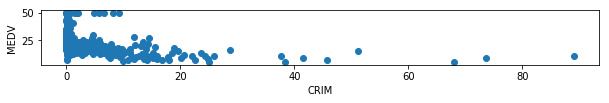

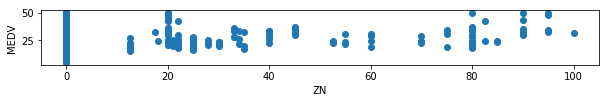

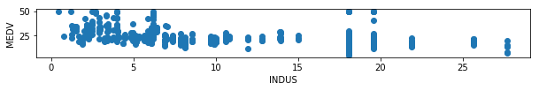

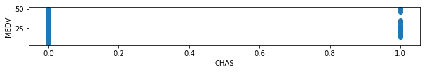

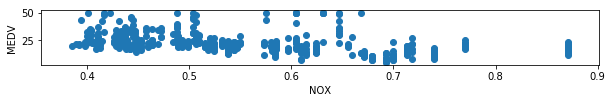

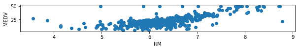

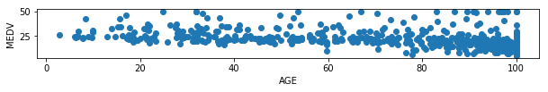

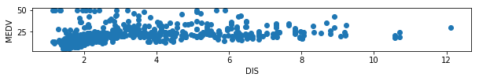

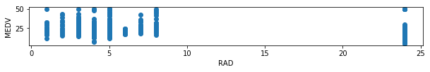

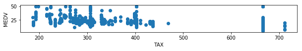

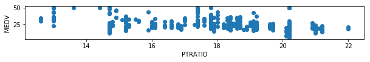

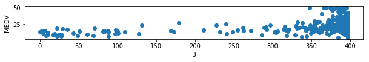

[21 more figures not shown]

```python
for i in boston.columns:
    if (i != 'MEDV'):
        plt.figure(figsize = (10, 1))
        plt.scatter(boston[i], boston['MEDV'])
        plt.xlabel(i)
        plt.ylabel('MEDV')
        plt.show()
```

# 2 A few simple models

## 2.1 Loss function

```python
import matplotlib.pyplot as plt
import numpy as np
from matplotlib import cm

def meanquadraticloss(lm, x, y):
    return np.square(y - lm.predict(x)).mean()
```

## 2.2 A few simple regressions

### 2.2.1 Create small model

```python
from sklearn.linear_model import LinearRegression

y = boston['MEDV']
x = boston[['AGE']]

lm = LinearRegression()
lm.fit(x, y)
```

```
LinearRegression(copy_X=True, fit_intercept=True, n_jobs=1, normalize=False)
```

### 2.2.2 10-fold cross-validate this model to get the average MSE score (your loss function).

```python
from sklearn.model_selection import cross_val_score

crossvalscore = cross_val_score(lm, x, y, cv=10, scoring=meanquadraticloss)
print('MSE score')
print(crossvalscore)
print('Average MSE score with 10-fold Cross-Validation: ', crossvalscore.mean())
```

```
MSE score
[  27.17512535   36.39634806    9.1318996   177.66453883   95.42894116
  151.03700784   38.13073964  153.30620778   72.13884353   22.09832012]
Average MSE score with 10-fold Cross-Validation:  78.2507971912
```

### 2.2.3 Now take next model with 10 features. Include more features you consider relevant but also the ones you consider irrelevant. Compute 10-fold MSE for this model.

```python
x = boston[['CRIM', 'PTRATIO*B', 'INDUS', 'CHAS', 'NOX', 'RM', 'B1', 'B3', 'B9', 'TAX']]
y = boston['MEDV']

lm = LinearRegression()
lm.fit(x, y)
print('MSE score')
print(cross_val_score(lm, x, y, cv=10, scoring=meanquadraticloss))
print("Average MSE score with 10 features: ", cross_val_score(lm, x, y, cv=10, scoring=meanquadraticloss).mean())
```

```
MSE score
[  21.91980395    7.06849469   11.99766053   63.89143101   32.01718349
   35.08441429   10.63031109  208.34041317  111.97582843   13.54005523]
Average MSE score with 10 features:  51.6465595867
```

### 2.2.4. Finally, include all your features and compute MSE. We call this the full model below.

```python
x = boston.drop(['MEDV'], axis=1)
y = boston['MEDV']

lm = LinearRegression()
lm.fit(x, y)

print("MSE score")
print(cross_val_score(lm, x, y, cv=10, scoring=meanquadraticloss))
print("Average MSE score with all features: ", cross_val_score(lm, x, y, cv=10, scoring=meanquadraticloss).mean())
```

```
MSE score
[  10.47327457   10.15450872   14.93050861   38.24713156   29.03605904
   33.52172722   12.24731527  157.58823704  138.63567908   14.87585543]
Average MSE score with all features:  45.9710296528
```

### 2.2.5 Compare the results

As MSE gets closer to zero, the model performs better result. I believe that MSE of the all the features have best model, because it has lowest average MSE score.

# 3 Find the best model

## 3.1 Can we evaluate all models?

### 3.1.1. How many different linear regression models can you build based on the features you have (including the ones you generated)?

```python
import math
print("Number of different linear regression models: ", math.factorial(len(x.columns)))
```

```
Number of different linear regression models:  8683317618811886495518194401280000000
```

### 3.1.2. Run a test: run the following loop a number of times so that the total execution time is reasonably long (at least 5 seconds) but not too long.

```python
import time

temp = boston.drop(['MEDV'], axis=1)
arange = np.arange(0, 33)

start = time.time()
for i in range(220):
    random = np.random.choice(arange, size=33, replace=False)
    numFeature = np.random.randint(low=1, high=34)
    picker = random[0:numFeature]

    x = temp.iloc[:, picker]
    y = boston['MEDV']

    lm = LinearRegression()
    lm.fit(x, y)

    score = cross_val_score(lm, x, y, cv=10, scoring=meanquadraticloss)
    mean = score.mean()
end = time.time()
print("Time: ", end - start)
```

```
Time:  5.846002817153931
```

```python
print("Time: ", ((5.5/250) * math.factorial(33)) / 31540000)
```

```
Time:  6.056848053705184e+27
```

## 3.2 Foward Selection

### 3.2.1. Read Whitten, Frank, Hall Ch7 (on canvas, files-readings), in particular section 7.1 (attribute selection).

### 3.2.2. Create a series of 1-feature models and pick the best one by 10-fold CV.

```python
temp = boston.drop(['MEDV'], axis=1)
name = temp.columns

bestScore = cross_val_score(lm, temp.iloc[:, 0].values.reshape(-1, 1), boston['MEDV'], cv=10, scoring=meanquadraticloss)
bestMean = bestScore.mean()
bestName = name[0]
for i in range(33):
    x = temp.iloc[:, i].values.reshape(-1, 1)
    y = boston['MEDV']
    #print(i)
    lm = LinearRegression()
    lm.fit(x, y)

    score = cross_val_score(lm, x, y, cv=10, scoring=meanquadraticloss)
    mean = score.mean()

    if (bestMean > mean):
        bestMean = mean
        bestName = name[i]

print("Best/Lowest Loss: ", bestMean)
print("Best Feature Name: ", bestName)
```

```
Best/Lowest Loss:  41.8289580722
Best Feature Name:  LSTAT
```

### 3.2.3. Pick the feature with the lowest loss. This is your 1-feature model.

LSTAT with 41.8289580722 loss (lowest)

### 3.2.4. Repeat the procedure with more features until the loss does not improve any more. This is your forward-selection model.

```python
temp = boston.drop(['MEDV'], axis=1)
name = temp.columns


arange = np.arange(0, 33)
shuffle = np.random.choice(arange, size=33, replace=False)
picker = shuffle[0:1]

x = temp.iloc[:, picker]
y = boston['MEDV']
lm = LinearRegression()
lm.fit(x, y)

score = cross_val_score(lm, x, y, cv=10, scoring=meanquadraticloss)
bestMean = score.mean()
featureNumber = 2


for i in range(1, 33):
    shuffle = np.random.choice(arange, size=33, replace=False)
    picker = shuffle[0:i]

    x = temp.iloc[:, picker]
    y = boston['MEDV']

    lm = LinearRegression()
    lm.fit(x, y)

    scoreMean = cross_val_score(lm, x, y, cv=10, scoring=meanquadraticloss).mean()

    if (bestMean > scoreMean):
        bestMean = scoreMean
        featureNumber = i + 1
print("Best/Lowest Loss: ", bestMean)
print("Number of features: ", featureNumber)
```

```
Best/Lowest Loss:  29.4599874068
Number of features:  23
```

```python
temp = boston.drop(['MEDV'], axis=1)
name = temp.columns
x = temp.iloc[:, 0:1]
y = boston['MEDV']

lm = LinearRegression()
lm.fit(x, y)

bestMean = cross_val_score(lm, x, y, cv=10, scoring=meanquadraticloss).mean()
featureNumber = 2

for i in range(1, 33):
    x = temp.iloc[:, 0:i]
    y = boston['MEDV']

    lm = LinearRegression()
    lm.fit(x, y)

    scoreMean = cross_val_score(lm, x, y, cv=10, scoring=meanquadraticloss).mean()

    if (bestMean > scoreMean):
        bestMean = scoreMean
        featureNumber = i + 1
print("Best/Lowest Loss: ", bestMean)
print("Number of features: ", featureNumber)
```

```
Best/Lowest Loss:  34.7630915054
Number of features:  14
```

# 4 Principal components

## 4.1 Use raw features

### 4.1.1. Consult Whitten, Frank, Hall (on canvas, files-readings), in particular section 7.3.

### 4.1.2. Perform Principal Component Analysis on all the features in your data (except the price, medv). Extract all components (the number should equal to the number of features) and report:

```python
from sklearn.decomposition import PCA

temp = boston.drop(['MEDV'], axis=1)
column = temp.columns

pca = PCA().fit(temp)
summary = pd.DataFrame(pca.explained_variance_, columns = ['Variance'], index=column)
summary['Proportional Variance'] = pca.explained_variance_ratio_
summary['Cumulative Variance'] = np.cumsum(pca.explained_variance_)
summary
```

|  | Variance | Proportional Variance | Cumulative Variance |
| --- | --- | --- | --- |
| CRIM | 7.136049e+08 | 6.212806e-01 | 7.136049e+08 |
| ZN | 4.311943e+08 | 3.754075e-01 | 1.144799e+09 |
| INDUS | 3.206177e+06 | 2.791370e-03 | 1.148005e+09 |
| CHAS | 3.237883e+05 | 2.818974e-04 | 1.148329e+09 |
| NOX | 2.431932e+05 | 2.117295e-04 | 1.148572e+09 |
| RM | 1.779008e+04 | 1.548845e-05 | 1.148590e+09 |
| AGE | 6.583302e+03 | 5.731572e-06 | 1.148597e+09 |
| DIS | 4.240246e+03 | 3.691654e-06 | 1.148601e+09 |
| RAD | 1.005674e+03 | 8.755627e-07 | 1.148602e+09 |
| TAX | 6.468286e+02 | 5.631436e-07 | 1.148603e+09 |
| PTRATIO | 2.014953e+02 | 1.754264e-07 | 1.148603e+09 |
| B | 1.880579e+02 | 1.637274e-07 | 1.148603e+09 |
| LSTAT | 6.616266e+01 | 5.760271e-08 | 1.148603e+09 |
| AGE*TAX | 5.353988e+01 | 4.661303e-08 | 1.148603e+09 |
| CRIM/AGE | 4.355032e+01 | 3.791589e-08 | 1.148603e+09 |
| CRIM/B | 4.118961e+01 | 3.586061e-08 | 1.148603e+09 |
| CRIM**2 | 1.390160e+01 | 1.210304e-08 | 1.148603e+09 |
| NOX**3 | 1.055294e+01 | 9.187627e-09 | 1.148603e+09 |
| RM*DIS | 4.189836e+00 | 3.647766e-09 | 1.148603e+09 |
| PTRATIO*B | 3.929187e+00 | 3.420839e-09 | 1.148603e+09 |
| INDUS/NOX | 1.987583e+00 | 1.730435e-09 | 1.148603e+09 |
| ZN*INDUS | 1.442085e+00 | 1.255512e-09 | 1.148603e+09 |
| B/RM | 1.323668e+00 | 1.152415e-09 | 1.148603e+09 |
| B1 | 1.218151e+00 | 1.060550e-09 | 1.148603e+09 |
| B2 | 1.150659e+00 | 1.001790e-09 | 1.148603e+09 |
| B3 | 1.065629e-01 | 9.277609e-11 | 1.148603e+09 |
| B4 | 7.966015e-02 | 6.935393e-11 | 1.148603e+09 |
| B5 | 5.956249e-02 | 5.185645e-11 | 1.148603e+09 |
| B6 | 5.589072e-02 | 4.865973e-11 | 1.148603e+09 |
| B7 | 1.979357e-02 | 1.723273e-11 | 1.148603e+09 |
| B8 | 1.239130e-03 | 1.078814e-12 | 1.148603e+09 |
| B9 | 1.130912e-04 | 9.845973e-14 | 1.148603e+09 |
| B10 | 5.833730e-05 | 5.078977e-14 | 1.148603e+09 |

### 4.1.3. Rotate data: rotate the original features according to the principal components. Most packages have this function built-in but you can consult Rajarman et al section 11.2.1 for details and interpretation.

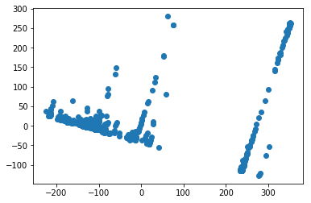

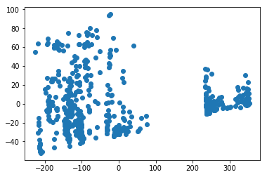

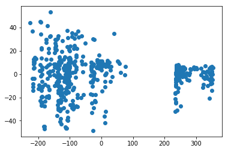

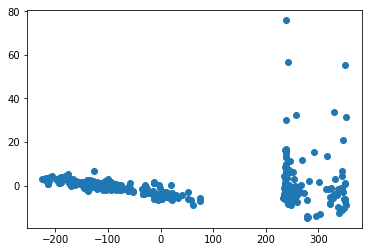

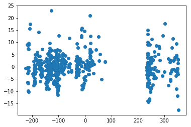

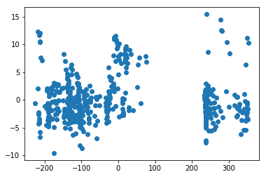

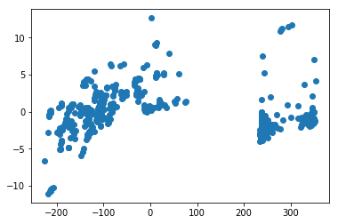

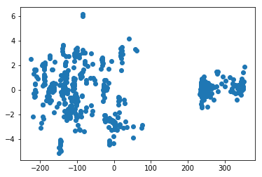

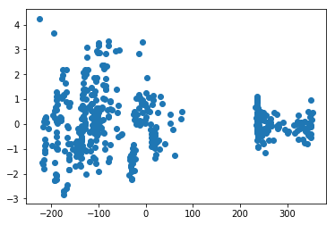

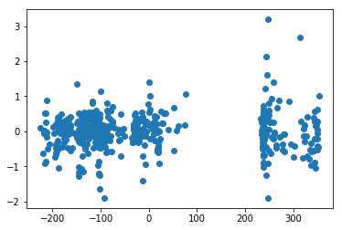

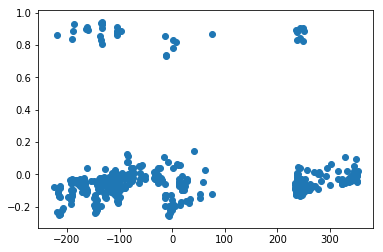

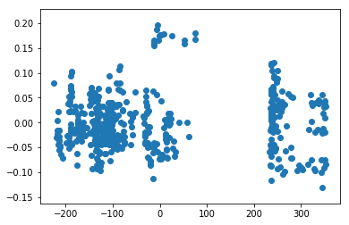

```
Rotation Matrix:  [[ -1.19818213e+02  -5.56072403e+00  -3.17255716e+00 ...,   3.77864866e-01
   -7.14419234e-02   3.35601653e-02]
 [ -1.68889931e+02   1.01141970e+01  -3.07818528e+01 ...,   4.80642168e-02
   -9.48218694e-02  -3.31213461e-02]
 [ -1.69311506e+02   1.40785539e+01  -1.67536418e+01 ...,  -4.68348169e-01
   -1.07330420e-01  -4.44679120e-03]
 ...,
 [ -1.38386700e+02   9.36859233e-01  -3.72850733e+01 ...,  -2.98531518e-01
   -1.04735416e-01   4.31279438e-02]
 [ -1.37504734e+02   4.25059832e+00  -3.59882682e+01 ...,  -1.94722041e-01
   -9.55415018e-02   4.51444687e-02]
 [ -1.39189872e+02   1.00782973e+00  -2.97723299e+01 ...,   4.15724707e-01
   -7.04680630e-02   4.55799864e-02]]
Rotation Variance:  [  3.08284717e+04   6.23792169e+03   8.16747922e+02   2.66155981e+02
   5.00356236e+01   2.78416349e+01   1.60690855e+01   9.51546794e+00
   3.26682587e+00   1.17875328e+00   2.54601972e-01   5.99823841e-02
   3.04748580e-03]
```

```python
boston = pd.DataFrame(bdata.data, columns = bdata.feature_names)

rotation = PCA().fit_transform(boston)

for i in range(13):
    if (i != 0):
        plt.scatter(rotation[:, 0], rotation[:, i])
        plt.show()
print("Rotation Matrix: ", rotation)
print("Rotation Variance: ", np.apply_along_axis(np.var, 0, rotation))
```

### 4.1.4. Find the optimal model in rotated data: estimate the regression model explaining the housing value by the rotated features. Start with the first (most important) rotated feature and add rotated features to the model one-by-one. Each time cross-validate your result. Stop where the cross-validation score starts to deteriorate.

```python
boston = pd.DataFrame(bdata.data, columns = bdata.feature_names)
y = bdata.target
x = rotation[:, 0].reshape(-1, 1)

lm = LinearRegression()
lm.fit(x, y)
mean = cross_val_score(lm, x, y, cv=10, scoring=meanquadraticloss).mean()
resultFeature = boston.columns[0]
resultMean = mean

for i in range(13):
    x = rotation[:, i].reshape(-1, 1)

    lm = LinearRegression()
    lm.fit(x, y)
    mean = cross_val_score(lm, x, y, cv=10, scoring=meanquadraticloss).mean()

    if (resultMean > mean):
        resultMean = mean
        resultFeature = boston.columns[0]

print("Best Mean: ", resultMean)
print("Best Feature: ", resultFeature)
```

```
Best Mean:  70.0810877952
Best Feature:  CRIM
```

## 4.2 PCA on normalized data

### 4.2.1. Code such a function and apply this to all explanatory variables in your data. This gives you a normalized data matrix Xn.

```python
def normal(n):
    return (n - np.mean(n)) / np.std(n)
```

```python
for i in boston.columns:
    boston[i] = normal(boston[i])

boston
```

|  | CRIM | ZN | INDUS | CHAS | NOX | RM | AGE | DIS | RAD | TAX | PTRATIO | B | LSTAT |
| --- | --- | --- | --- | --- | --- | --- | --- | --- | --- | --- | --- | --- | --- |
| 0 | -0.417713 | 0.284830 | -1.287909 | -0.272599 | -0.144217 | 0.413672 | -0.120013 | 0.140214 | -0.982843 | -0.666608 | -1.459000 | 0.441052 | -1.075562 |
| 1 | -0.415269 | -0.487722 | -0.593381 | -0.272599 | -0.740262 | 0.194274 | 0.367166 | 0.557160 | -0.867883 | -0.987329 | -0.303094 | 0.441052 | -0.492439 |
| 2 | -0.415272 | -0.487722 | -0.593381 | -0.272599 | -0.740262 | 1.282714 | -0.265812 | 0.557160 | -0.867883 | -0.987329 | -0.303094 | 0.396427 | -1.208727 |
| 3 | -0.414680 | -0.487722 | -1.306878 | -0.272599 | -0.835284 | 1.016303 | -0.809889 | 1.077737 | -0.752922 | -1.106115 | 0.113032 | 0.416163 | -1.361517 |
| 4 | -0.410409 | -0.487722 | -1.306878 | -0.272599 | -0.835284 | 1.228577 | -0.511180 | 1.077737 | -0.752922 | -1.106115 | 0.113032 | 0.441052 | -1.026501 |
| 5 | -0.414974 | -0.487722 | -1.306878 | -0.272599 | -0.835284 | 0.207096 | -0.351157 | 1.077737 | -0.752922 | -1.106115 | 0.113032 | 0.410571 | -1.043322 |
| 6 | -0.408169 | 0.048772 | -0.476654 | -0.272599 | -0.265154 | -0.388411 | -0.070229 | 0.839244 | -0.523001 | -0.577519 | -1.505237 | 0.426798 | -0.031268 |
| 7 | -0.401618 | 0.048772 | -0.476654 | -0.272599 | -0.265154 | -0.160466 | 0.978808 | 1.024638 | -0.523001 | -0.577519 | -1.505237 | 0.441052 | 0.910700 |
| 8 | -0.393853 | 0.048772 | -0.476654 | -0.272599 | -0.265154 | -0.931206 | 1.117494 | 1.087196 | -0.523001 | -0.577519 | -1.505237 | 0.328448 | 2.421774 |
| 9 | -0.398650 | 0.048772 | -0.476654 | -0.272599 | -0.265154 | -0.399808 | 0.616090 | 1.329635 | -0.523001 | -0.577519 | -1.505237 | 0.329325 | 0.623344 |
| 10 | -0.392264 | 0.048772 | -0.476654 | -0.272599 | -0.265154 | 0.131589 | 0.914799 | 1.212979 | -0.523001 | -0.577519 | -1.505237 | 0.393028 | 1.092926 |
| 11 | -0.404771 | 0.048772 | -0.476654 | -0.272599 | -0.265154 | -0.392685 | 0.509409 | 1.155935 | -0.523001 | -0.577519 | -1.505237 | 0.441052 | 0.086478 |
| 12 | -0.407530 | 0.048772 | -0.476654 | -0.272599 | -0.265154 | -0.563644 | -1.051700 | 0.787143 | -0.523001 | -0.577519 | -1.505237 | 0.370880 | 0.428502 |
| 13 | -0.345121 | -0.487722 | -0.437258 | -0.272599 | -0.144217 | -0.478164 | -0.240919 | 0.433754 | -0.637962 | -0.601276 | 1.176466 | 0.441052 | -0.615792 |
| 14 | -0.344167 | -0.487722 | -0.437258 | -0.272599 | -0.144217 | -0.268740 | 0.566306 | 0.317003 | -0.637962 | -0.601276 | 1.176466 | 0.255974 | -0.335445 |
| 15 | -0.345397 | -0.487722 | -0.437258 | -0.272599 | -0.144217 | -0.642000 | -0.429390 | 0.334449 | -0.637962 | -0.601276 | 1.176466 | 0.427018 | -0.586356 |
| 16 | -0.295732 | -0.487722 | -0.437258 | -0.272599 | -0.144217 | -0.498110 | -1.396638 | 0.334449 | -0.637962 | -0.601276 | 1.176466 | 0.330860 | -0.851284 |
| 17 | -0.327139 | -0.487722 | -0.437258 | -0.272599 | -0.144217 | -0.419753 | 0.466736 | 0.220028 | -0.637962 | -0.601276 | 1.176466 | 0.329764 | 0.282722 |
| 18 | -0.324984 | -0.487722 | -0.437258 | -0.272599 | -0.144217 | -1.180521 | -1.137046 | 0.000693 | -0.637962 | -0.601276 | 1.176466 | -0.742112 | -0.134996 |
| 19 | -0.333939 | -0.487722 | -0.437258 | -0.272599 | -0.144217 | -0.794439 | 0.032897 | 0.000693 | -0.637962 | -0.601276 | 1.176466 | 0.375814 | -0.192467 |
| 20 | -0.272694 | -0.487722 | -0.437258 | -0.272599 | -0.144217 | -1.018110 | 1.049929 | 0.001358 | -0.637962 | -0.601276 | 1.176466 | 0.218147 | 1.172825 |
| 21 | -0.319240 | -0.487722 | -0.437258 | -0.272599 | -0.144217 | -0.455370 | 0.733440 | 0.103277 | -0.637962 | -0.601276 | 1.176466 | 0.393138 | 0.164976 |
| 22 | -0.274943 | -0.487722 | -0.437258 | -0.272599 | -0.144217 | -0.203205 | 0.822342 | 0.086449 | -0.637962 | -0.601276 | 1.176466 | 0.441052 | 0.850425 |
| 23 | -0.303359 | -0.487722 | -0.437258 | -0.272599 | -0.144217 | -0.671918 | 1.117494 | 0.142686 | -0.637962 | -0.601276 | 1.176466 | 0.415176 | 1.013027 |
| 24 | -0.331091 | -0.487722 | -0.437258 | -0.272599 | -0.144217 | -0.513781 | 0.907687 | 0.287388 | -0.637962 | -0.601276 | 1.176466 | 0.412874 | 0.511205 |
| 25 | -0.320579 | -0.487722 | -0.437258 | -0.272599 | -0.144217 | -0.976795 | 0.608978 | 0.313533 | -0.637962 | -0.601276 | 1.176466 | -0.583896 | 0.540641 |
| 26 | -0.340214 | -0.487722 | -0.437258 | -0.272599 | -0.144217 | -0.671918 | 0.772557 | 0.421632 | -0.637962 | -0.601276 | 1.176466 | 0.221545 | 0.302346 |
| 27 | -0.307162 | -0.487722 | -0.437258 | -0.272599 | -0.144217 | -0.338548 | 0.719216 | 0.312963 | -0.637962 | -0.601276 | 1.176466 | -0.551442 | 0.648575 |
| 28 | -0.328444 | -0.487722 | -0.437258 | -0.272599 | -0.144217 | 0.299699 | 0.918355 | 0.313581 | -0.637962 | -0.601276 | 1.176466 | 0.342811 | 0.020597 |
| 29 | -0.301726 | -0.487722 | -0.437258 | -0.272599 | -0.144217 | 0.554713 | 0.665875 | 0.211044 | -0.637962 | -0.601276 | 1.176466 | 0.258276 | -0.094346 |
| ... | ... | ... | ... | ... | ... | ... | ... | ... | ... | ... | ... | ... | ... |
| 476 | 0.148767 | -0.487722 | 1.015999 | -0.272599 | 0.512296 | 0.284028 | 0.889907 | -0.708178 | 1.661245 | 1.530926 | 0.806576 | 0.433487 | 0.844819 |
| 477 | 1.330841 | -0.487722 | 1.015999 | -0.272599 | 0.512296 | -1.397069 | 1.021481 | -0.805438 | 1.661245 | 1.530926 | 0.806576 | -0.078878 | 1.718101 |
| 478 | 0.773058 | -0.487722 | 1.015999 | -0.272599 | 0.512296 | -0.141945 | 1.000145 | -0.772257 | 1.661245 | 1.530926 | 0.806576 | 0.252465 | 0.753706 |
| 479 | 1.250534 | -0.487722 | 1.015999 | -0.272599 | 0.512296 | -0.079260 | 0.690768 | -0.876506 | 1.661245 | 1.530926 | 0.806576 | 0.292156 | 0.064051 |
| 480 | 0.259685 | -0.487722 | 1.015999 | -0.272599 | -0.196047 | -0.060739 | -0.137794 | -0.176287 | 1.661245 | 1.530926 | 0.806576 | 0.441052 | -0.268161 |
| 481 | 0.246198 | -0.487722 | 1.015999 | -0.272599 | -0.196047 | 0.662987 | 0.224924 | -0.220259 | 1.661245 | 1.530926 | 0.806576 | 0.399058 | -0.688683 |
| 482 | 0.248874 | -0.487722 | 1.015999 | -0.272599 | -0.196047 | 1.106056 | 0.299601 | -0.182752 | 1.661245 | 1.530926 | 0.806576 | 0.423290 | -0.791010 |
| 483 | -0.090284 | -0.487722 | 1.015999 | -0.272599 | -0.196047 | -0.744576 | -1.005472 | 0.144159 | 1.661245 | 1.530926 | 0.806576 | 0.397414 | -0.313017 |
| 484 | -0.141494 | -0.487722 | 1.015999 | -0.272599 | 0.244507 | -0.589288 | -0.948575 | -0.033772 | 1.661245 | 1.530926 | 0.806576 | 0.154115 | 0.096291 |
| 485 | 0.009304 | -0.487722 | 1.015999 | -0.272599 | 0.244507 | 0.038987 | -0.592969 | 0.093485 | 1.661245 | 1.530926 | 0.806576 | 0.350267 | -0.290589 |
| 486 | 0.244285 | -0.487722 | 1.015999 | -0.272599 | 0.244507 | -0.243096 | 0.399171 | -0.118435 | 1.661245 | 1.530926 | 0.806576 | 0.394782 | 0.326176 |
| 487 | 0.144605 | -0.487722 | 1.015999 | -0.272599 | 0.244507 | -0.540849 | -0.546740 | -0.305540 | 1.661245 | 1.530926 | 0.806576 | 0.345881 | -0.168638 |
| 488 | -0.400883 | -0.487722 | 2.422565 | -0.272599 | 0.469104 | -1.183370 | 0.857902 | -0.938447 | -0.637962 | 1.798194 | 0.760340 | 0.421206 | 0.757911 |
| 489 | -0.397098 | -0.487722 | 2.422565 | -0.272599 | 0.469104 | -1.240357 | 1.057042 | -0.969583 | -0.637962 | 1.798194 | 0.760340 | -0.138414 | 1.586338 |
| 490 | -0.394293 | -0.487722 | 2.422565 | -0.272599 | 0.469104 | -1.697672 | 1.046373 | -0.937638 | -0.637962 | 1.798194 | 0.760340 | -0.419321 | 2.386730 |
| 491 | -0.406137 | -0.487722 | 2.422565 | -0.272599 | 0.469104 | -0.429726 | 1.074822 | -0.916009 | -0.637962 | 1.798194 | 0.760340 | 0.366604 | 0.759313 |
| 492 | -0.405487 | -0.487722 | 2.422565 | -0.272599 | 0.469104 | -0.429726 | 0.530745 | -0.801065 | -0.637962 | 1.798194 | 0.760340 | 0.441052 | 0.097692 |
| 493 | -0.398269 | -0.487722 | -0.211099 | -0.272599 | 0.261784 | -0.822932 | -0.518292 | -0.671859 | -0.408041 | -0.102376 | 0.344213 | 0.441052 | -0.090141 |
| 494 | -0.385897 | -0.487722 | -0.211099 | -0.272599 | 0.261784 | -0.510932 | -0.923682 | -0.671859 | -0.408041 | -0.102376 | 0.344213 | 0.441052 | 0.131334 |
| 495 | -0.397608 | -0.487722 | -0.211099 | -0.272599 | 0.261784 | -0.875644 | -1.414418 | -0.473678 | -0.408041 | -0.102376 | 0.344213 | 0.401471 | 0.693431 |
| 496 | -0.384729 | -0.487722 | -0.211099 | -0.272599 | 0.261784 | -1.274549 | 0.153803 | -0.473678 | -0.408041 | -0.102376 | 0.344213 | 0.441052 | 1.189646 |
| 497 | -0.387200 | -0.487722 | -0.211099 | -0.272599 | 0.261784 | -0.698987 | 0.072014 | -0.428946 | -0.408041 | -0.102376 | 0.344213 | 0.441052 | 0.202823 |
| 498 | -0.390607 | -0.487722 | -0.211099 | -0.272599 | 0.261784 | -0.378438 | -0.116457 | -0.658834 | -0.408041 | -0.102376 | 0.344213 | 0.441052 | 0.037418 |
| 499 | -0.397743 | -0.487722 | -0.211099 | -0.272599 | 0.261784 | -1.019535 | 0.175139 | -0.663208 | -0.408041 | -0.102376 | 0.344213 | 0.428662 | 0.342996 |
| 500 | -0.392323 | -0.487722 | -0.211099 | -0.272599 | 0.261784 | -0.367041 | 0.395615 | -0.616479 | -0.408041 | -0.102376 | 0.344213 | 0.441052 | 0.235063 |
| 501 | -0.411157 | -0.487722 | 0.115738 | -0.272599 | 0.158124 | 0.439316 | 0.018673 | -0.625796 | -0.982843 | -0.803212 | 1.176466 | 0.387217 | -0.418147 |
| 502 | -0.413178 | -0.487722 | 0.115738 | -0.272599 | 0.158124 | -0.234548 | 0.288933 | -0.716639 | -0.982843 | -0.803212 | 1.176466 | 0.441052 | -0.500850 |
| 503 | -0.411374 | -0.487722 | 0.115738 | -0.272599 | 0.158124 | 0.984960 | 0.797449 | -0.773684 | -0.982843 | -0.803212 | 1.176466 | 0.441052 | -0.983048 |
| 504 | -0.405689 | -0.487722 | 0.115738 | -0.272599 | 0.158124 | 0.725672 | 0.736996 | -0.668437 | -0.982843 | -0.803212 | 1.176466 | 0.403225 | -0.865302 |
| 505 | -0.412929 | -0.487722 | 0.115738 | -0.272599 | 0.158124 | -0.362767 | 0.434732 | -0.613246 | -0.982843 | -0.803212 | 1.176466 | 0.441052 | -0.669058 |

506 rows × 13 columns

### 4.2.2 Repeat the analysis in 4.1 with normalized data.

```python
column = boston.columns

pca = PCA().fit(boston)
summary = pd.DataFrame(pca.explained_variance_, columns = ['Variance'], index=column)
summary['Proportional Variance'] = pca.explained_variance_ratio_
summary['Cumulative Variance'] = np.cumsum(pca.explained_variance_)
summary
```

|  | Variance | Proportional Variance | Cumulative Variance |
| --- | --- | --- | --- |
| CRIM | 6.134779 | 0.470973 | 6.134779 |
| ZN | 1.434899 | 0.110159 | 7.569678 |
| INDUS | 1.243621 | 0.095474 | 8.813299 |
| CHAS | 0.859498 | 0.065985 | 9.672796 |
| NOX | 0.836219 | 0.064197 | 10.509015 |
| RM | 0.660957 | 0.050742 | 11.169972 |
| AGE | 0.540085 | 0.041463 | 11.710057 |
| DIS | 0.397329 | 0.030503 | 12.107386 |
| RAD | 0.277984 | 0.021341 | 12.385370 |
| TAX | 0.220696 | 0.016943 | 12.606066 |
| PTRATIO | 0.186533 | 0.014320 | 12.792599 |
| B | 0.169502 | 0.013013 | 12.962101 |
| LSTAT | 0.063641 | 0.004886 | 13.025743 |

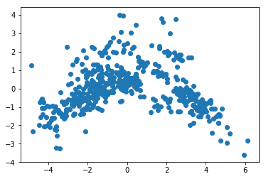

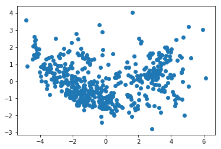

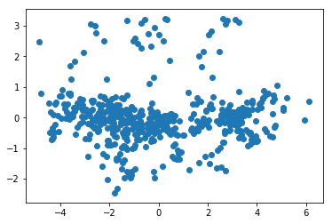

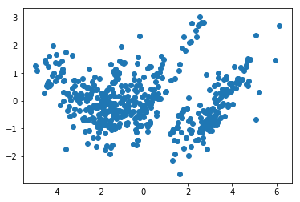

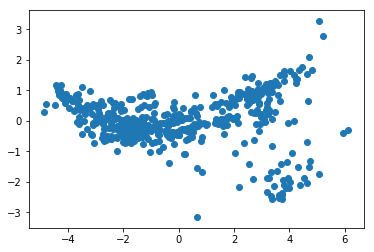

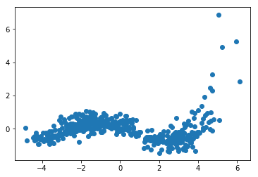

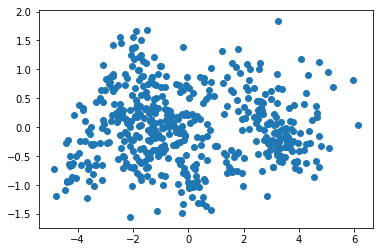

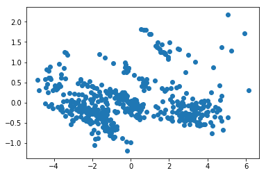

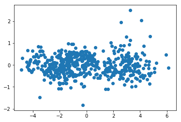

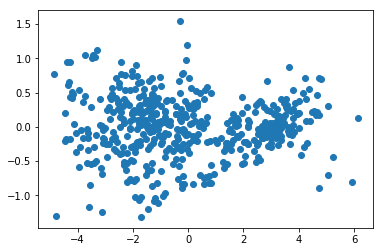

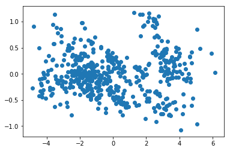

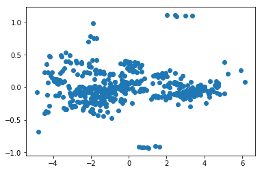

```
Rotation Matrix:  [[-2.09784245  0.7771017   0.33507618 ..., -0.03180387  0.01861057
   0.36576452]
 [-1.45641223  0.58808833 -0.70134048 ..., -0.64075966 -0.12491686
  -0.07101921]
 [-2.07415237  0.60218543  0.16123374 ..., -0.4870395   0.13451097
  -0.01418981]
 ...,
 [-0.31101606  1.15182721 -0.41645927 ...,  0.11947043  0.28222212
   0.06235813]
 [-0.26916176  1.03671761 -0.59260478 ...,  0.09076144  0.30193584
   0.05425615]
 [-0.1242658   0.75197455 -1.30005539 ...,  0.18883684  0.23232661
   0.01943888]]
Rotation Variance:  [ 6.12265476  1.43206335  1.24116299  0.85779892  0.83456618  0.65965056
  0.53901749  0.39654415  0.27743495  0.22025981  0.18616388  0.16916744
  0.06351553]
```

```python
rotation = PCA().fit_transform(boston)
rotation
for i in range(13):
    if (i != 0):
        plt.scatter(rotation[:, 0], rotation[:, i])
        plt.show()
print("Rotation Matrix: ", rotation)
print("Rotation Variance: ", np.apply_along_axis(np.var, 0, rotation))
```

## 4.3 What's the best solution?

### Compare all your results: full model, forward selection, PCA on raw data, and PCA on normalized data. Which one is the most precise? Which one is the most compact? Which one is the easiest to do? Which one is the most straightforward to interpret?

Most precise: based on the result, most precise result is the one with the smallest loss which is forward selection in my data, but the best is PCA normalized logically, because it normalized every rows and columns of the data, and analyze in scatter plot.

Easiest: Full model, becasue only step I needed to do was to used cross validation and implement mean quadratic function.

Straightforward to interpret: forward selection, because you can see loss score changes for each iteration